# Populate indicators using data for Hessequa Atlas Area

```
## $`Spilopelia senegalensis`
```

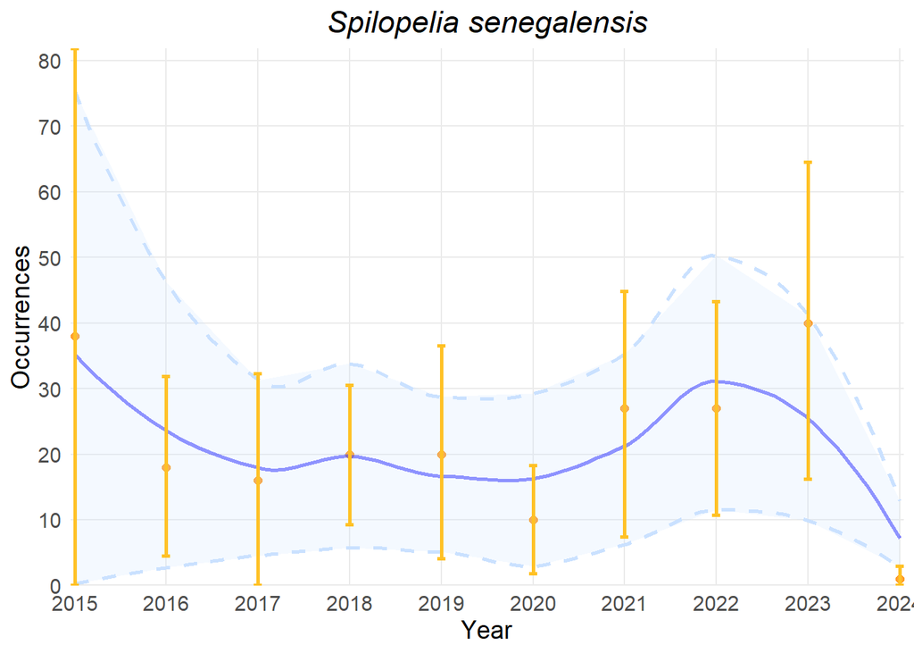

```r
plot(ts_spec_occ_unstruc_HAA_QDGC, species = "Spilopelia senegalensis")
```

Maps of occurrence - structured data

```
## $`Spilopelia senegalensis`
```

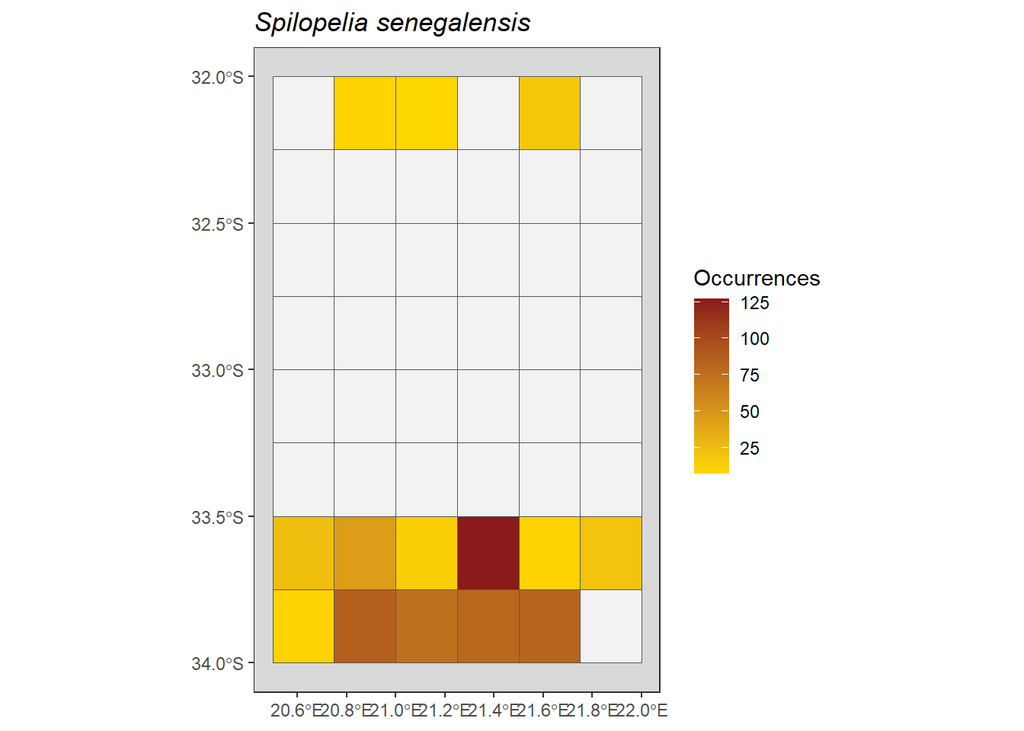

```r
map_spec_occ_sabap_HAA_QDGC <- spec_occ_map(HAASABAP2QDGC, cell_size = 0.25, level = "cube", region = "South Africa", ne_scale = "medium")

plot(map_spec_occ_sabap_HAA_QDGC, species = "Spilopelia senegalensis")
```

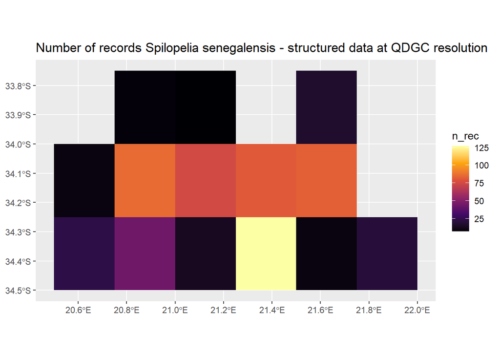

```r
SABAP2HAAQDGCGeom %>% filter(species == "Spilopelia senegalensis") %>%
  group_by(qdgc) %>%
  summarise(n_rec = n(), .groups = "drop") %>%
  ggplot() +
  geom_sf(aes(fill = n_rec), col = alpha("white", 0)) +
  scale_fill_viridis_c(option = "inferno") +
  ggtitle("Number of records Spilopelia senegalensis - structured data at QDGC resolution")
```

Time series of occurrence - structured data

```r
ts_spec_occ_sabap_HAA_QDGC <- spec_occ_ts(HAASABAP2QDGC, cell_size = 0.25, level = "cube", region = "South Africa", ne_scale = "medium")
```

[output not shown]

[output cut: 42 more lines]

```
## $`Spilopelia senegalensis`
```

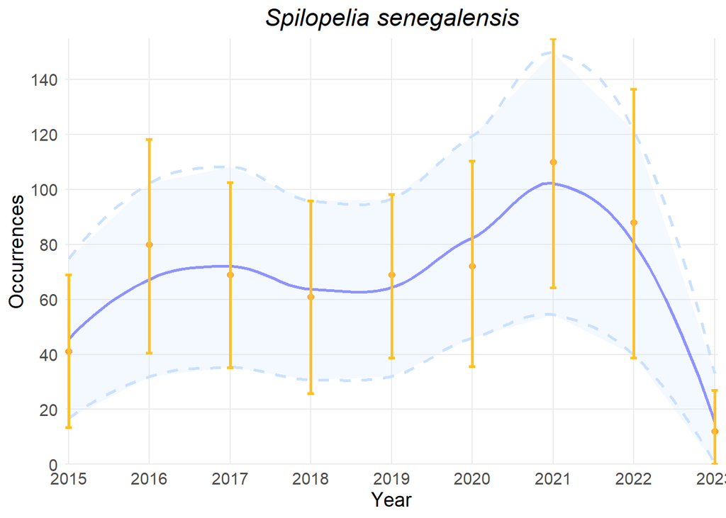

```r
plot(ts_spec_occ_sabap_HAA_QDGC, species = "Spilopelia senegalensis")
```

Maps of range - unstructured data

```
## $`Spilopelia senegalensis`
```

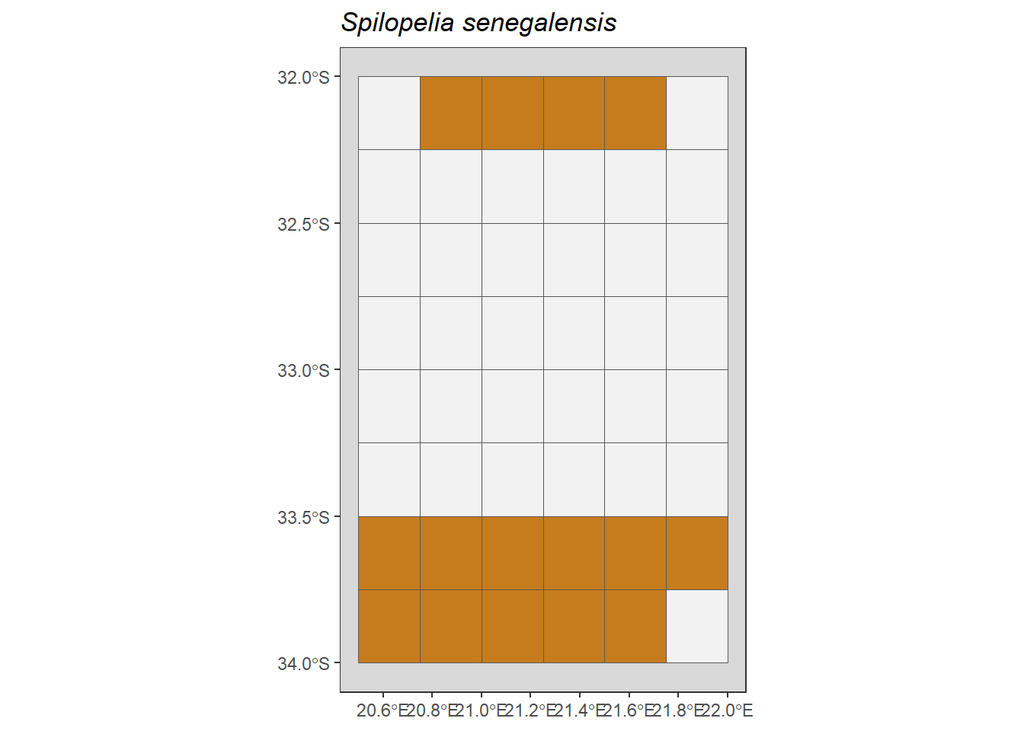

```r
map_spec_range_unstruc_HAA_QDGC <- spec_range_map(HAAunstrucQDGCproc, cell_size = 0.25, level = "cube", region = "South Africa", ne_scale = "medium")

plot(map_spec_range_unstruc_HAA_QDGC, species = "Spilopelia senegalensis")
```

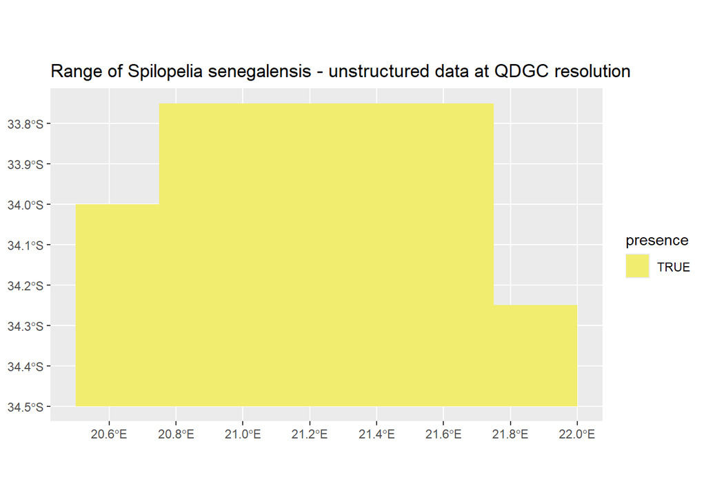

```r
UnstrucHAAQDGCinterim %>% filter(species == "Spilopelia senegalensis") %>% group_by(qdgc) %>%
  summarise(n_rec = sum(n), .groups = "drop") %>%
  mutate(presence=case_when((n_rec > 0)~TRUE,
                                  TRUE~FALSE)) %>%
  ggplot() +
  geom_sf(aes(fill = presence), col = alpha("white", 0)) +
  scale_fill_manual(values = "#F1ED6FFF") +
  ggtitle("Range of Spilopelia senegalensis - unstructured data at QDGC resolution")
```

```r
ts_spec_range_unstruc_HAA_QDGC <- spec_range_ts(HAAunstrucQDGCproc, cell_size = 0.25, level = "cube", region = "South Africa", ne_scale = "medium")
```

[output not shown]

[output cut: 71 more lines]

```
## $`Spilopelia senegalensis`
```

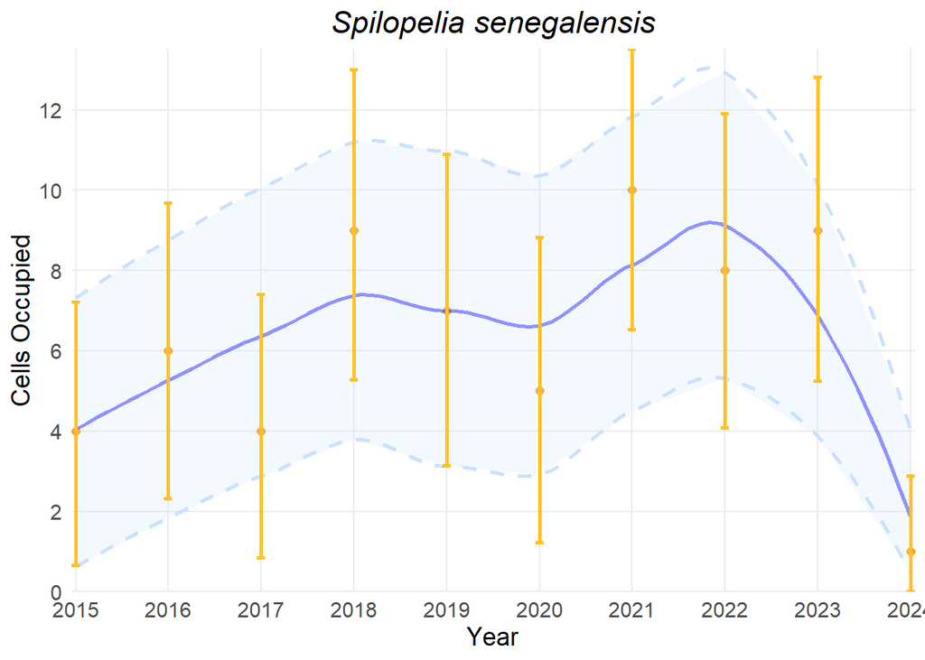

```r
plot(ts_spec_range_unstruc_HAA_QDGC, species = "Spilopelia senegalensis")
```

Maps of range - structured data

```
## $`Spilopelia senegalensis`
```

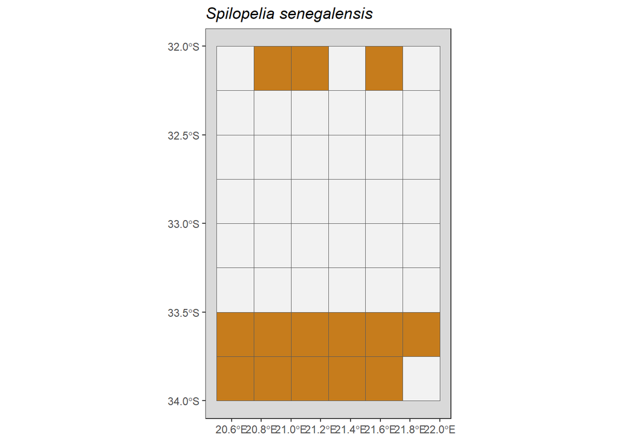

```r
map_spec_range_sabap_HAA_QDGC <- spec_range_map(HAASABAP2QDGC, cell_size = 0.25, level = "cube", region = "South Africa", ne_scale = "medium")

plot(map_spec_range_sabap_HAA_QDGC, species = "Spilopelia senegalensis")
```

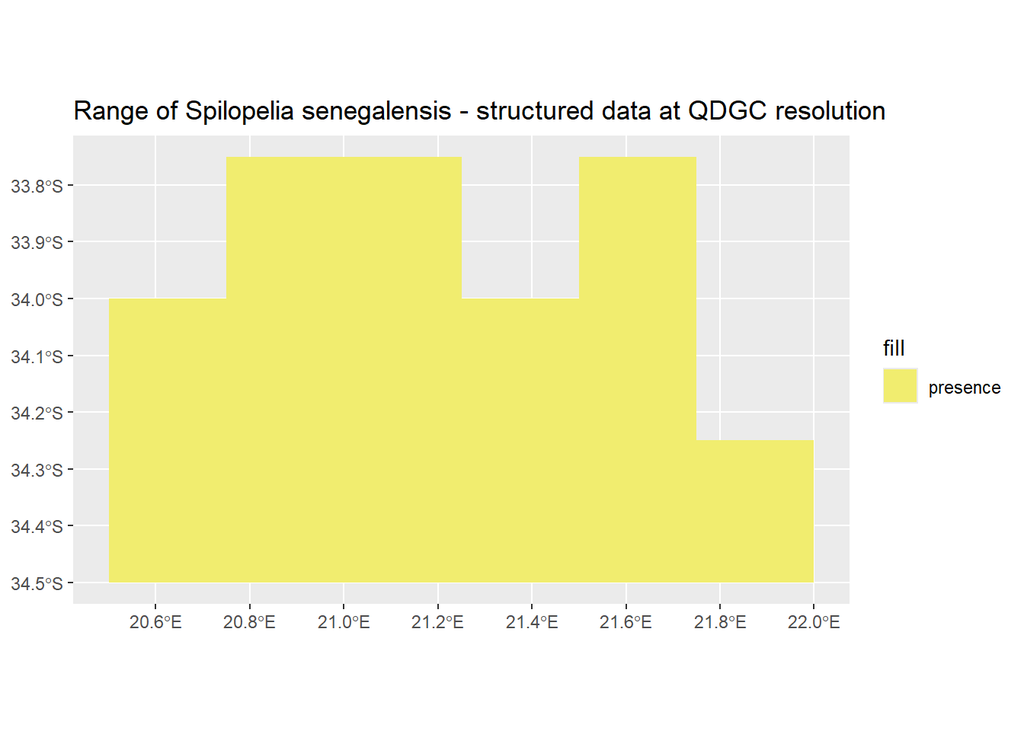

```r
SABAP2HAAQDGCGeom %>% filter(species == "Spilopelia senegalensis") %>% group_by(qdgc) %>%
  summarise(n_rec = n(), .groups = "drop") %>%
  mutate(presence=case_when((n_rec > 0)~TRUE,
                                  TRUE~FALSE)) %>%
  ggplot() +
  geom_sf(aes(fill = "presence"), col = alpha("white", 0)) +
  scale_fill_manual(values = "#F1ED6FFF") +
  ggtitle("Range of Spilopelia senegalensis - structured data at QDGC resolution")
```

Time series of range - structured data

```r
ts_spec_range_sabap_HAA_QDGC <- spec_range_ts(HAASABAP2QDGC, cell_size = 0.25, level = "cube", region = "South Africa", ne_scale = "medium")
```

[output not shown]

[output cut: 311 more lines]

```
## $`Spilopelia senegalensis`
```

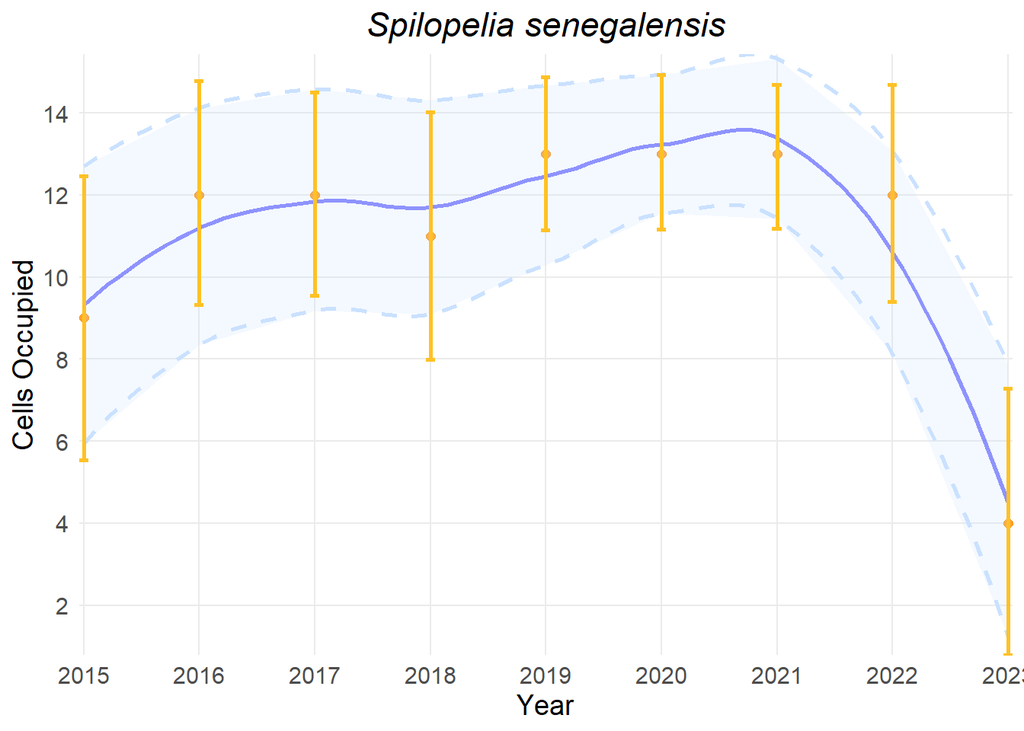

```r
plot(ts_spec_range_sabap_HAA_QDGC, species = "Spilopelia senegalensis")
```

#### Pentad resolution

Maps of occurrence - unstructured data

```r
map_spec_occ_unstruc_HAA_pen <- spec_occ_map(HAAunstruc, cell_size = 0.08333333, level = "cube", region = "South Africa", ne_scale = "medium")

plot(map_spec_occ_unstruc_HAA_pen, species = "Spilopelia senegalensis")
```

[output not shown]

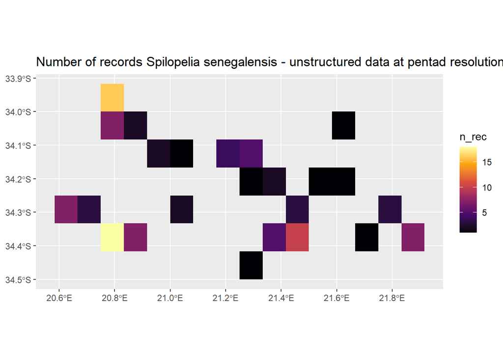

```r
UnstrucHAAinterim %>% filter(species == "Spilopelia senegalensis") %>% group_by(pentad) %>%
  summarise(n_rec = sum(n), .groups = "drop") %>%
  ggplot() +
  geom_sf(aes(fill = n_rec), col = alpha("white", 0)) +
  scale_fill_viridis_c(option = "inferno") +
  ggtitle("Number of records Spilopelia senegalensis - unstructured data at pentad resolution")
```

Time series of occurrence - unstructured data

```r
ts_spec_occ_unstruc_HAA_pen <- spec_occ_ts(HAAunstruc, cell_size = 0.08333333, level = "cube", region = "South Africa", ne_scale = "medium")
```

[output not shown]

[output cut: 52 more lines]

```
## $`Spilopelia senegalensis`
```

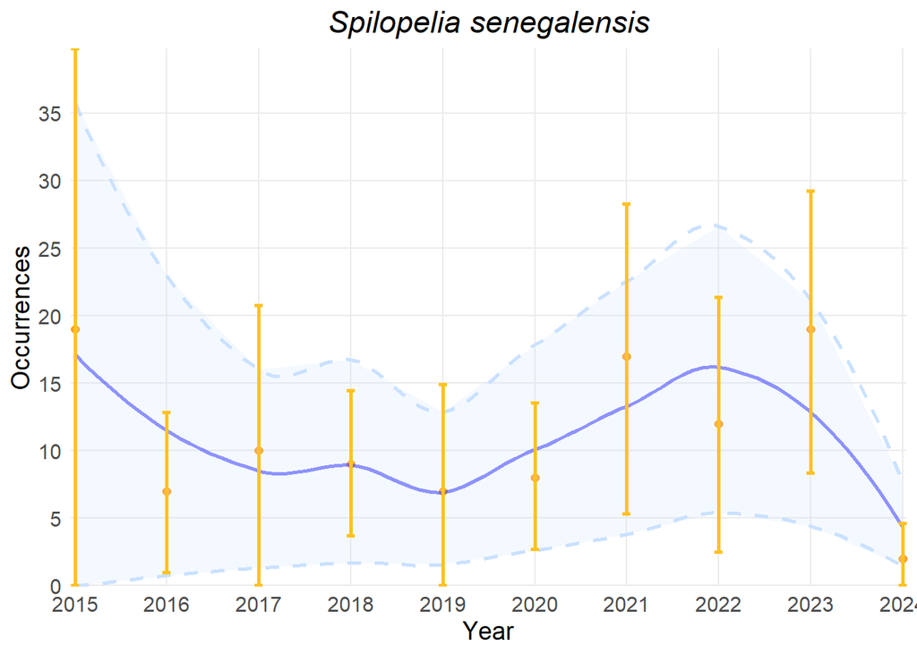

```r
plot(ts_spec_occ_unstruc_HAA_pen, species = "Spilopelia senegalensis")
```

Maps of occurrence - structured data

```r
map_spec_occ_sabap_HAA_pen <- spec_occ_map(HAASABAP2, cell_size = 0.08333333, level = "cube", region = "South Africa", ne_scale = "medium")

plot(map_spec_occ_sabap_HAA_pen, species = "Spilopelia senegalensis")
```

[output not shown]

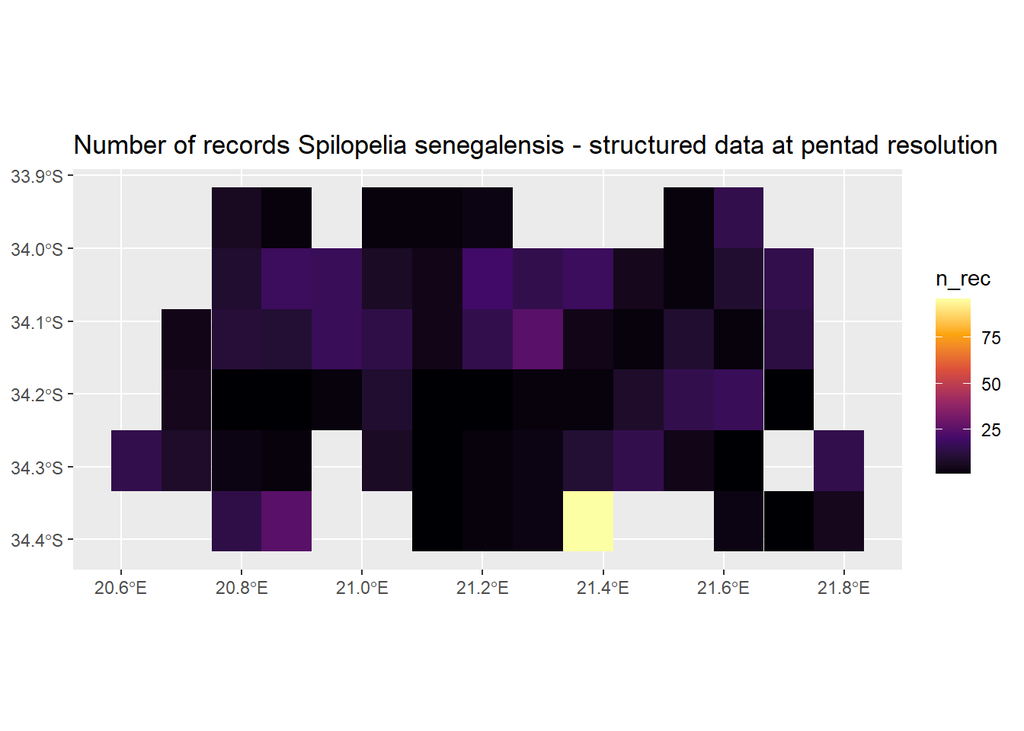

```r
SABAP2HAAGeom %>% filter(species == "Spilopelia senegalensis") %>%
  group_by(pentad) %>%
  summarise(n_rec = n(), .groups = "drop") %>%
  ggplot() +
  geom_sf(aes(fill = n_rec), col = alpha("white", 0)) +
  scale_fill_viridis_c(option = "inferno") +
  ggtitle("Number of records Spilopelia senegalensis - structured data at pentad resolution")
```

Time series of occurrence - structured data

```r
ts_spec_occ_sabap_HAA_pen <- spec_occ_ts(HAASABAP2, cell_size = 0.08333333, level = "cube", region = "South Africa", ne_scale = "medium")
```

[output not shown]

[output cut: 32 more lines]

```
## $`Spilopelia senegalensis`
```

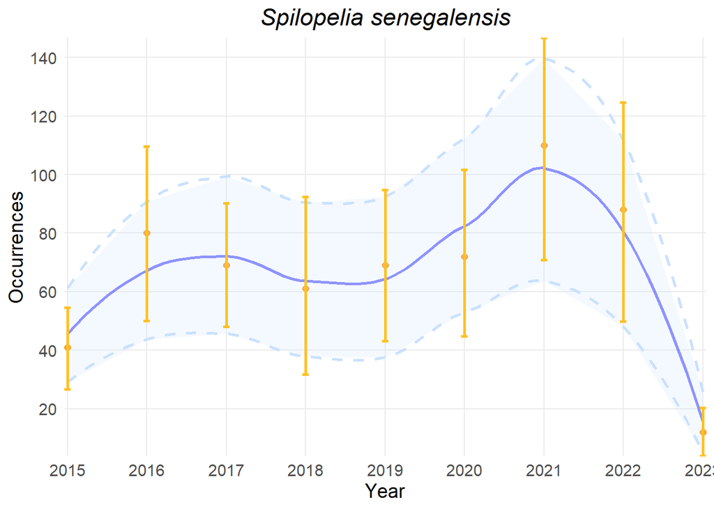

```r
plot(ts_spec_occ_sabap_HAA_pen, species = "Spilopelia senegalensis")
```

Maps of range - unstructured data

```r
map_spec_range_unstruc_HAA_pen <- spec_range_map(HAAunstruc, cell_size = 0.08333333, level = "cube", region = "South Africa", ne_scale = "medium")

plot(map_spec_range_unstruc_HAA_pen, species = "Spilopelia senegalensis")
```

[output not shown]

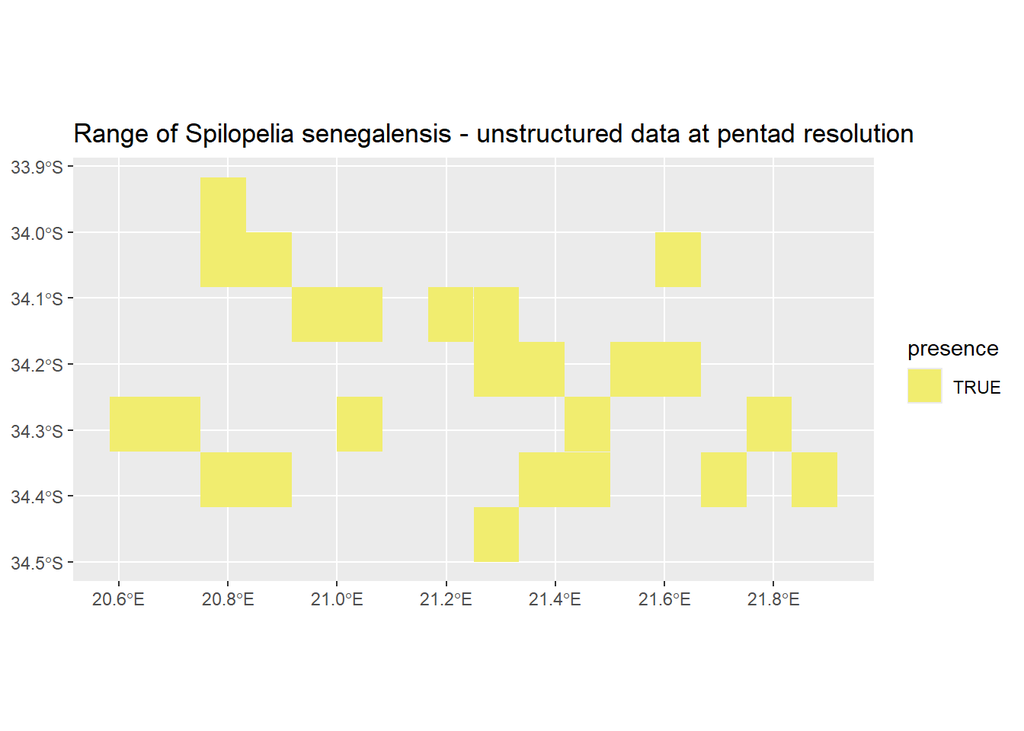

```r
UnstrucHAAinterim %>% filter(species == "Spilopelia senegalensis") %>% group_by(pentad) %>%
  summarise(n_rec = sum(n), .groups = "drop") %>%
  mutate(presence=case_when((n_rec > 0)~TRUE,
                                  TRUE~FALSE)) %>%
  ggplot() +
  geom_sf(aes(fill = presence), col = alpha("white", 0)) +
  scale_fill_manual(values = "#F1ED6FFF") +
  ggtitle("Range of Spilopelia senegalensis - unstructured data at pentad resolution")
```

```r
ts_spec_range_unstruc_HAA_pen <- spec_range_ts(HAAunstruc, cell_size = 0.08333333, level = "cube", region = "South Africa", ne_scale = "medium")
```

[output not shown]

[output cut: 61 more lines]

```
## $`Spilopelia senegalensis`
```

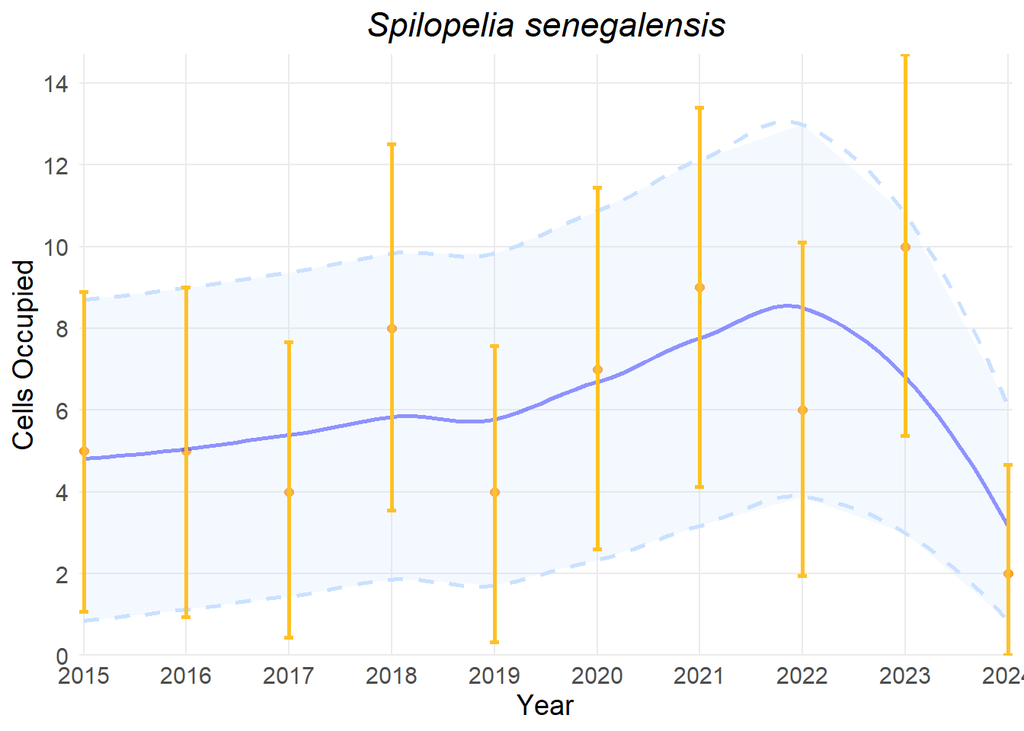

```r
plot(ts_spec_range_unstruc_HAA_pen, species = "Spilopelia senegalensis")
```

Maps of range - structured data

```r
map_spec_range_sabap_HAA_pen <- spec_range_map(HAASABAP2, cell_size = 0.08333333, level = "cube", region = "South Africa", ne_scale = "medium")

plot(map_spec_range_sabap_HAA_pen, species = "Spilopelia senegalensis")
```

[output not shown]

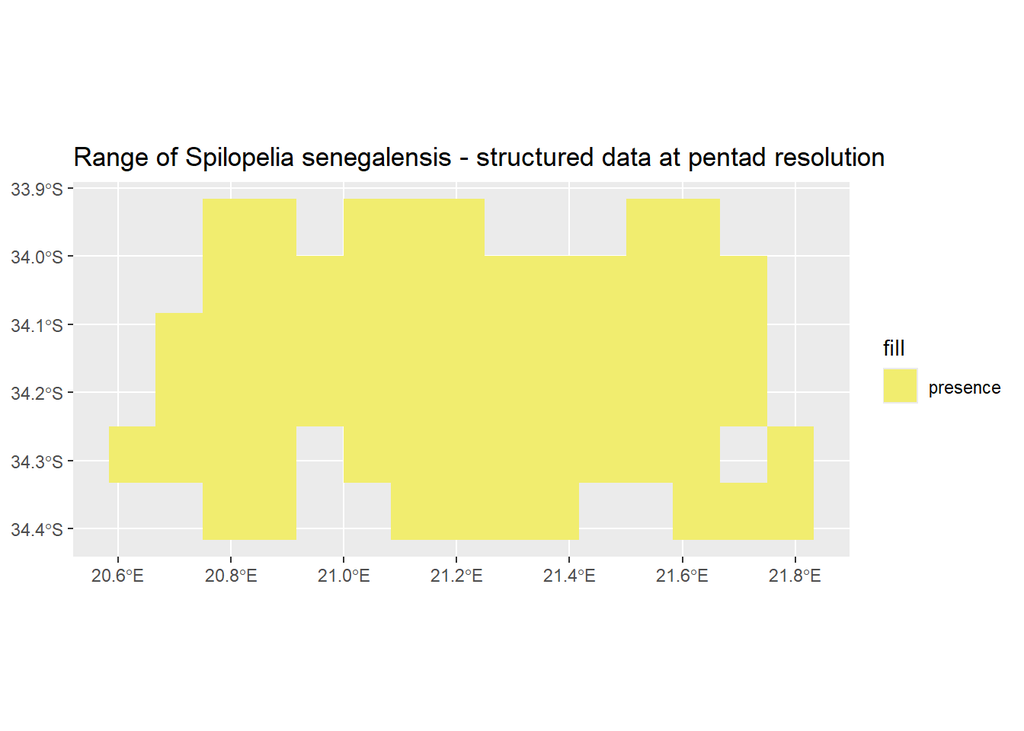

```r
SABAP2HAAGeom %>% filter(species == "Spilopelia senegalensis") %>% group_by(pentad) %>%
  summarise(n_rec = n(), .groups = "drop") %>%
  mutate(presence=case_when((n_rec > 0)~TRUE,
                                  TRUE~FALSE)) %>%
  ggplot() +
  geom_sf(aes(fill = "presence"), col = alpha("white", 0)) +
  scale_fill_manual(values = "#F1ED6FFF") +
  ggtitle("Range of Spilopelia senegalensis - structured data at pentad resolution")
```

Time series of range - structured data

```r
ts_spec_range_sabap_HAA_pen <- spec_range_ts(HAASABAP2, cell_size = 0.08333333, level = "cube", region = "South Africa", ne_scale = "medium")
```

[output not shown]

[output cut: 72 more lines]

```
## $`Spilopelia senegalensis`
```

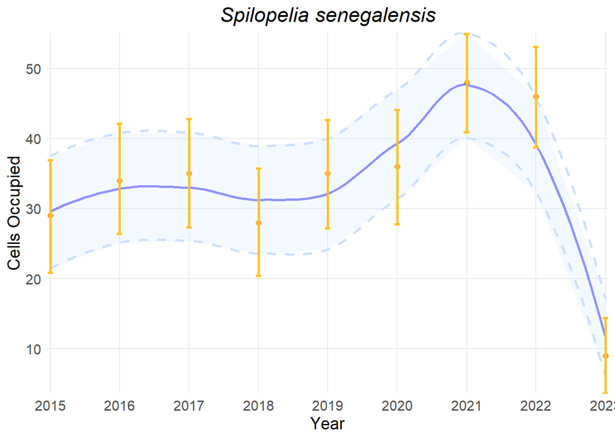

```r
plot(ts_spec_range_sabap_HAA_pen, species = "Spilopelia senegalensis")
```

**Anas erythrorhyncha** - a species for which records have decreased

#### Quarter-degree grid cell resolution

Maps of occurrence - unstructured data

```r
RecFullrange<-range(0,90)
```

```
## $`Anas erythrorhyncha`
```

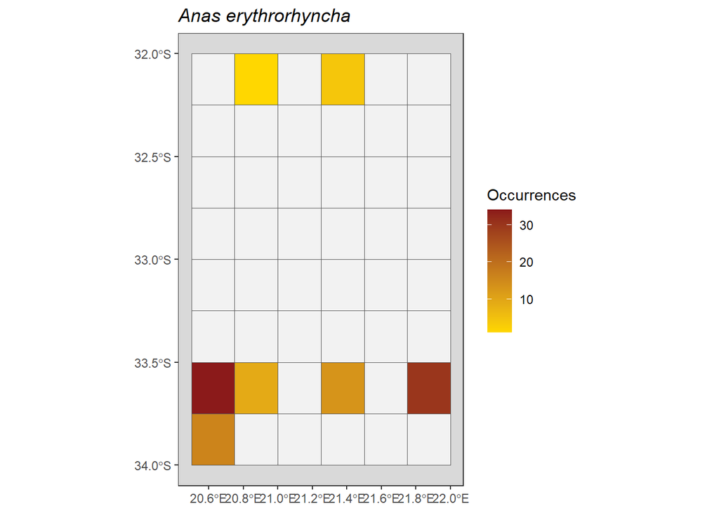

```r
plot(map_spec_occ_unstruc_HAA_QDGC, species = "Anas erythrorhyncha")
```

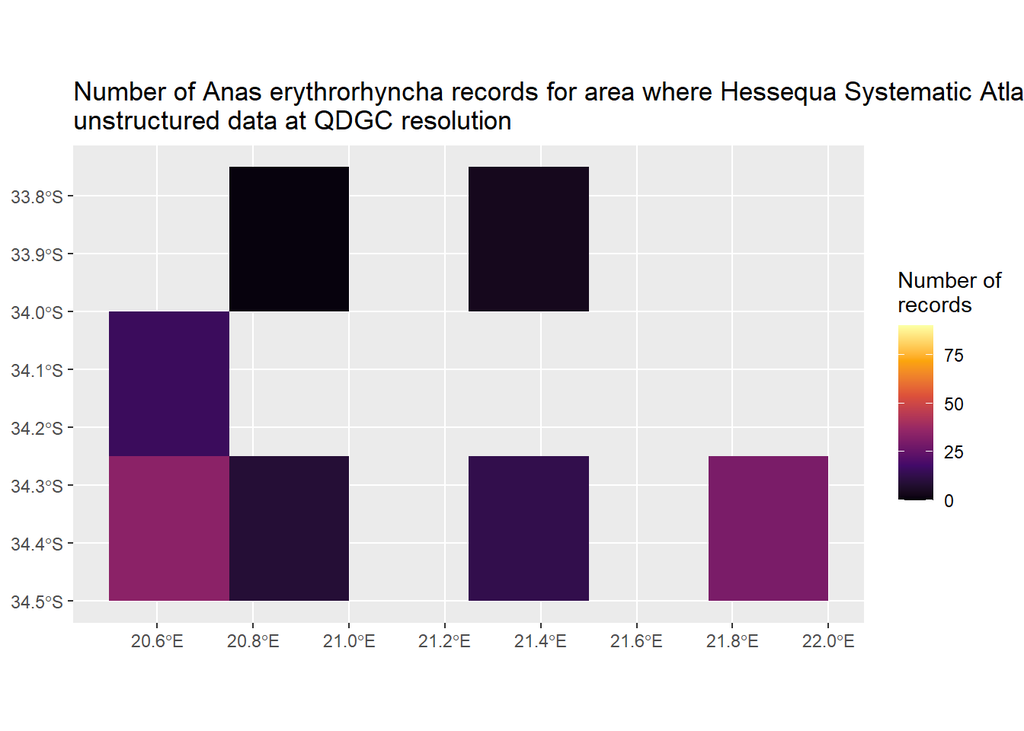

```r
UnstrucHAAQDGCinterim %>% filter(species == "Anas erythrorhyncha") %>% group_by(qdgc) %>%
  summarise(n_rec = sum(n), .groups = "drop") %>%
  ggplot() +
  geom_sf(aes(fill = n_rec), col = alpha("white", 0)) +
  scale_fill_viridis_c(option = "inferno", name = "Number of\nrecords", limits = RecFullrange) +
  ggtitle("Number of Anas erythrorhyncha records for area where Hessequa Systematic Atlassing Subproject is performed-\nunstructured data at QDGC resolution")
```

Time series of occurrence - unstructured data

```
## $`Anas erythrorhyncha`
```

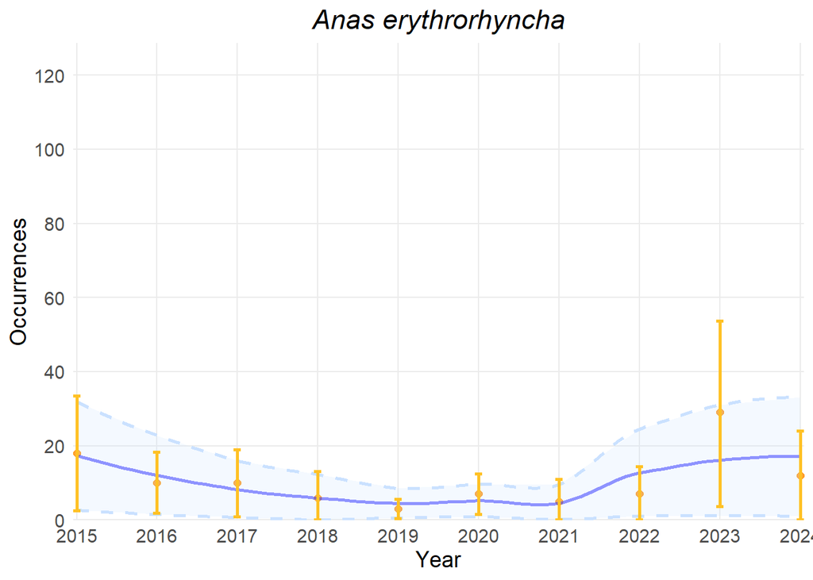

```r
plot(ts_spec_occ_unstruc_HAA_QDGC, species = "Anas erythrorhyncha", y_expand = c(0, 1.4))
```

Maps of occurrence - structured data

```
## $`Anas erythrorhyncha`
```

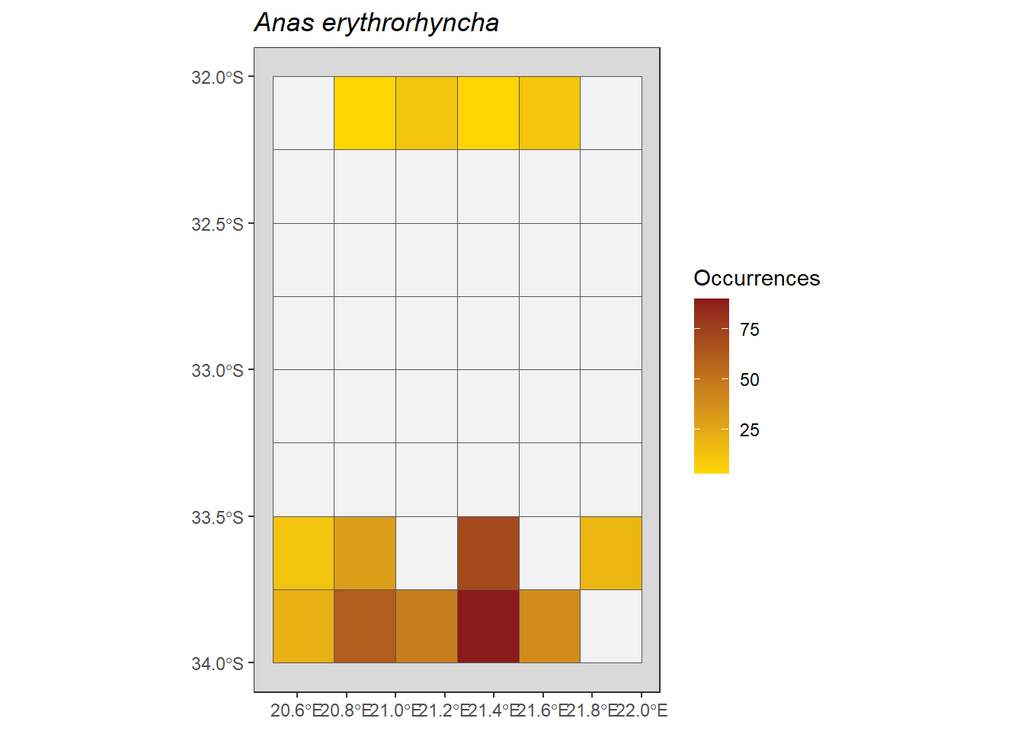

```r
plot(map_spec_occ_sabap_HAA_QDGC, species = "Anas erythrorhyncha")
```

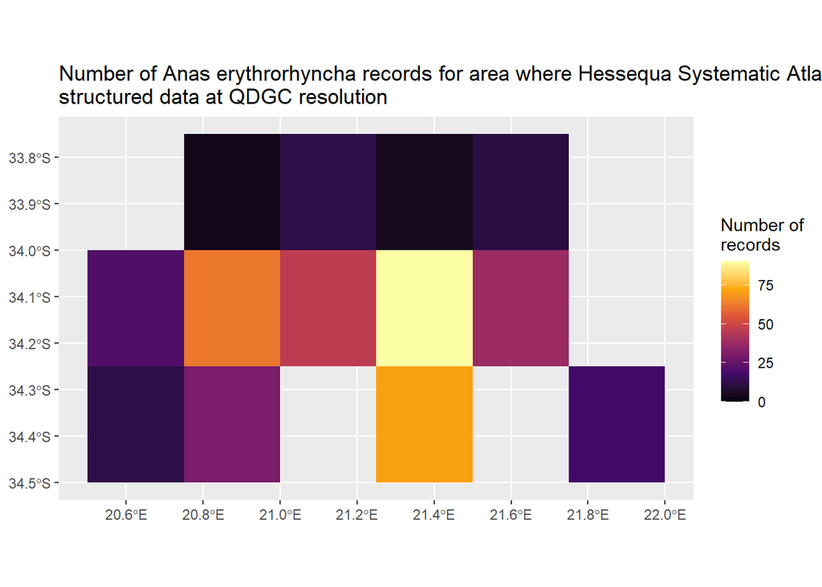

```r
SABAP2HAAQDGCGeom %>% filter(species == "Anas erythrorhyncha") %>%
  group_by(qdgc) %>%
  summarise(n_rec = n(), .groups = "drop") %>%
  ggplot() +
  geom_sf(aes(fill = n_rec), col = alpha("white", 0)) +
  scale_fill_viridis_c(option = "inferno", name = "Number of\nrecords", limits = RecFullrange) +
  ggtitle("Number of Anas erythrorhyncha records for area where Hessequa Systematic Atlassing Subproject is performed-\nstructured data at QDGC resolution")
```

Time series of occurrence - structured data

```
## $`Anas erythrorhyncha`
```

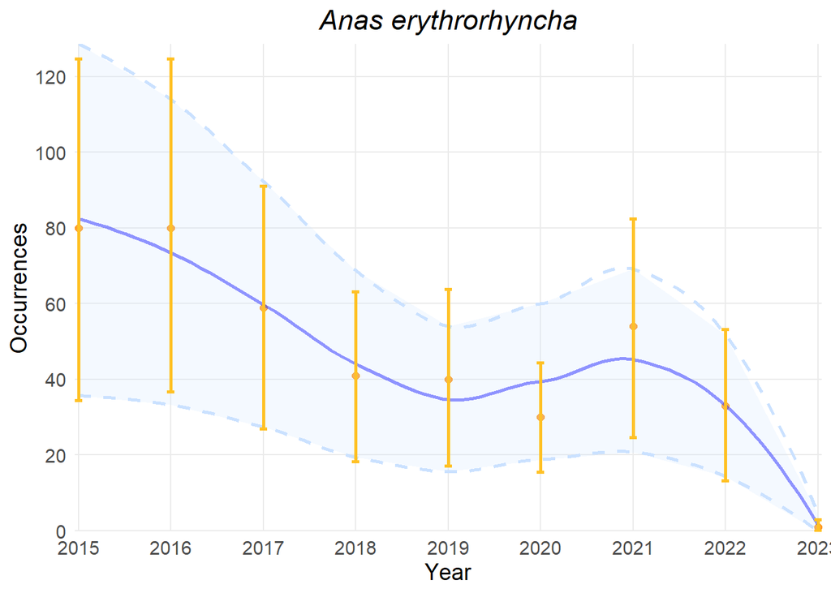

```r
plot(ts_spec_occ_sabap_HAA_QDGC, species = "Anas erythrorhyncha")
```

Maps of range - unstructured data

```
## $`Anas erythrorhyncha`
```

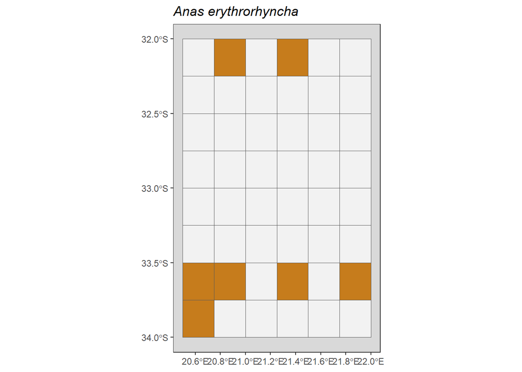

```r
plot(map_spec_range_unstruc_HAA_QDGC, species = "Anas erythrorhyncha")
```

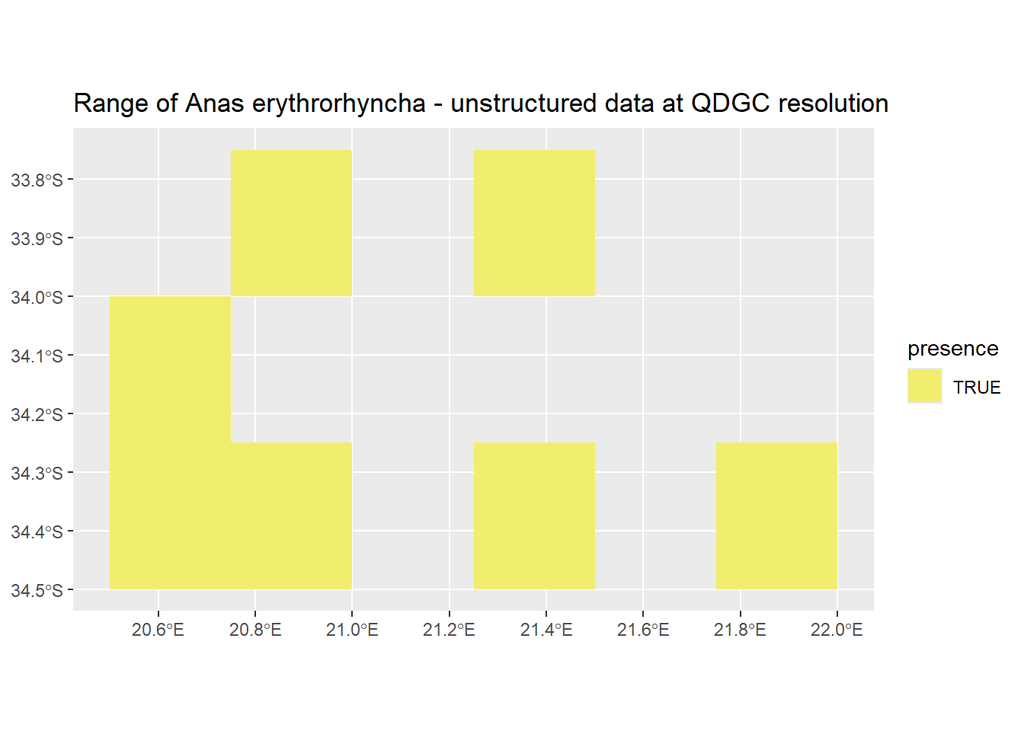

```r
UnstrucHAAQDGCinterim %>% filter(species == "Anas erythrorhyncha") %>% group_by(qdgc) %>%
  summarise(n_rec = sum(n), .groups = "drop") %>%
  mutate(presence=case_when((n_rec > 0)~TRUE,
                                  TRUE~FALSE)) %>%
  ggplot() +
  geom_sf(aes(fill = presence), col = alpha("white", 0)) +
  scale_fill_manual(values = "#F1ED6FFF") +
  ggtitle("Range of Anas erythrorhyncha - unstructured data at QDGC resolution")
```

Time series of range - unstructured data

```
## $`Anas erythrorhyncha`
```

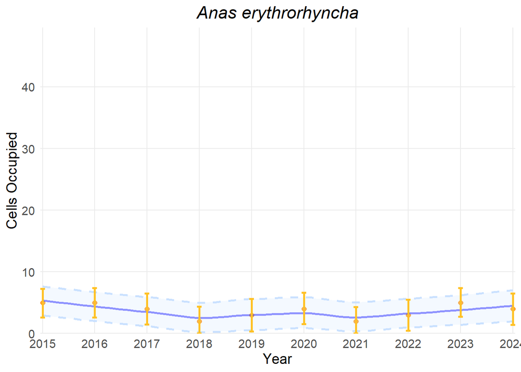

```r
plot(ts_spec_range_unstruc_HAA_QDGC, species = "Anas erythrorhyncha", y_expand = c(0, 5.5))
```

Maps of range - structured data

```
## $`Anas erythrorhyncha`
```

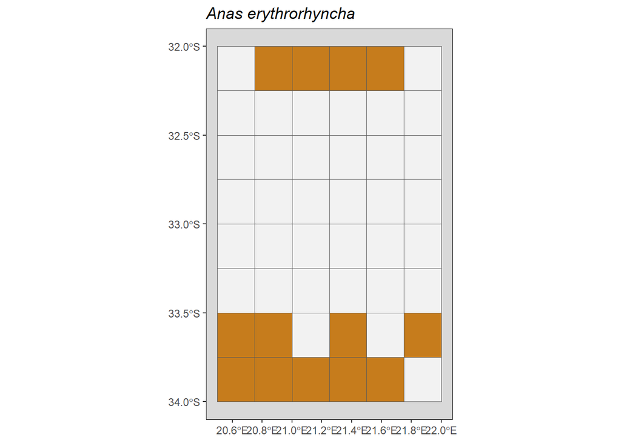

```r
plot(map_spec_range_sabap_HAA_QDGC, species = "Anas erythrorhyncha")
```

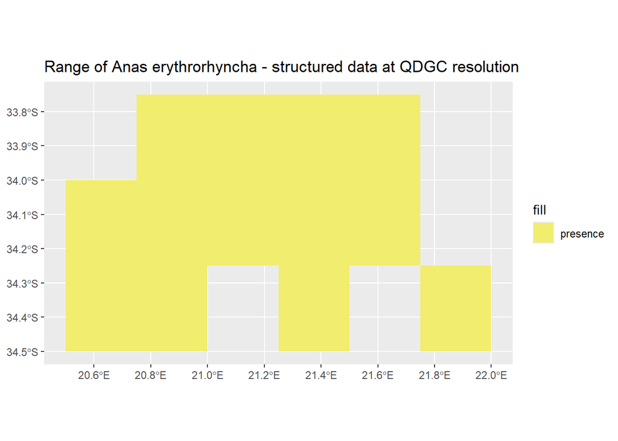

```r
SABAP2HAAQDGCGeom %>% filter(species == "Anas erythrorhyncha") %>% group_by(qdgc) %>%
  summarise(n_rec = n(), .groups = "drop") %>%
  mutate(presence=case_when((n_rec > 0)~TRUE,
                                  TRUE~FALSE)) %>%
  ggplot() +
  geom_sf(aes(fill = "presence"), col = alpha("white", 0)) +
  scale_fill_manual(values = "#F1ED6FFF") +
  ggtitle("Range of Anas erythrorhyncha - structured data at QDGC resolution")
```

Time series of range - structured data

```
## $`Anas erythrorhyncha`
```

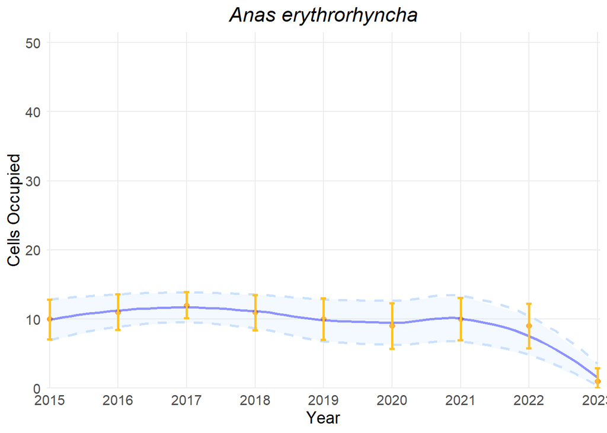

```r
plot(ts_spec_range_sabap_HAA_QDGC, species = "Anas erythrorhyncha",  y_expand = c(0, 2.7))
```

#### Pentad resolution

Maps of occurrence - unstructured data

```r
map_spec_occ_unstruc_HAA_pen <- spec_occ_map(HAAunstruc, cell_size = 0.08333333, level = "cube", region = "South Africa", ne_scale = "medium")

plot(map_spec_occ_unstruc_HAA_pen, species = "Anas erythrorhyncha")
```

[output not shown]

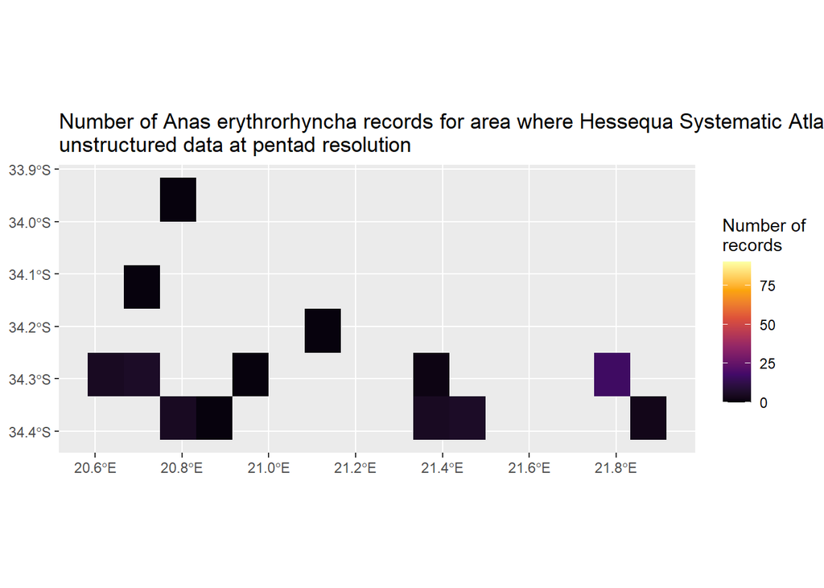

```r
UnstrucHAAinterim %>% filter(species == "Anas erythrorhyncha") %>% group_by(pentad) %>%
  summarise(n_rec = sum(n), .groups = "drop") %>%
  ggplot() +
  geom_sf(aes(fill = n_rec), col = alpha("white", 0)) +
  scale_fill_viridis_c(option = "inferno", name = "Number of\nrecords", limits = RecFullrange) +
  ggtitle("Number of Anas erythrorhyncha records for area where Hessequa Systematic Atlassing Subproject is performed-\nunstructured data at pentad resolution")
```

Time series of occurrence - unstructured data

```r
ts_spec_occ_unstruc_HAA_pen <- spec_occ_ts(HAAunstruc, cell_size = 0.08333333, level = "cube", region = "South Africa", ne_scale = "medium")
```

[output not shown]

[output cut: 52 more lines]

```
## $`Anas erythrorhyncha`
```

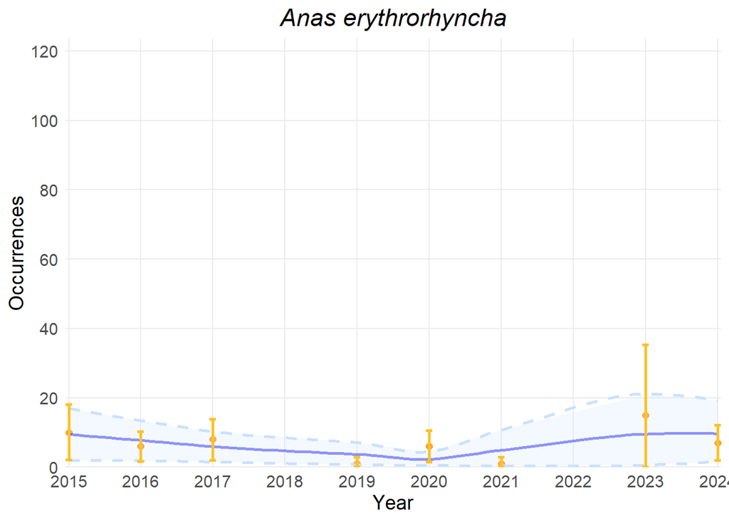

```r
plot(ts_spec_occ_unstruc_HAA_pen, species = "Anas erythrorhyncha", y_expand = c(0, 2.5))
```

Maps of occurrence - structured data

```r
map_spec_occ_sabap_HAA_pen <- spec_occ_map(HAASABAP2, cell_size = 0.08333333, level = "cube", region = "South Africa", ne_scale = "medium")

plot(map_spec_occ_sabap_HAA_pen, species = "Anas erythrorhyncha")
```

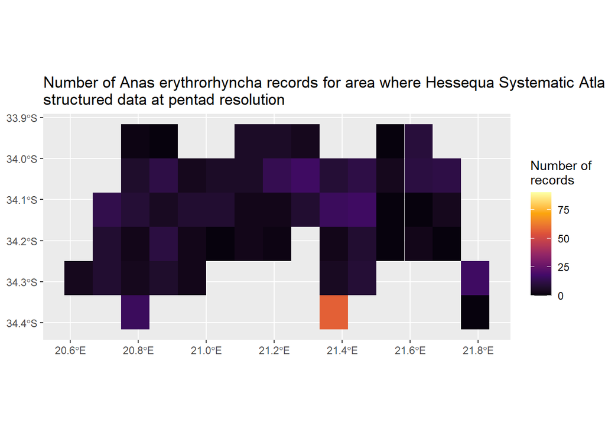

```r
SABAP2HAAGeom %>% filter(species == "Anas erythrorhyncha") %>%
  group_by(pentad) %>%
  summarise(n_rec = n(), .groups = "drop") %>%
  ggplot() +
  geom_sf(aes(fill = n_rec), col = alpha("white", 0)) +
  scale_fill_viridis_c(option = "inferno", name = "Number of\nrecords", limits = RecFullrange) +
  ggtitle("Number of Anas erythrorhyncha records for area where Hessequa Systematic Atlassing Subproject is performed-\nstructured data at pentad resolution")
```

Time series of occurrence - structured data

```r
ts_spec_occ_sabap_HAA_pen <- spec_occ_ts(HAASABAP2, cell_size = 0.08333333, level = "cube", region = "South Africa", ne_scale = "medium")
```

[output not shown]

[output cut: 32 more lines]

```
## $`Anas erythrorhyncha`
```

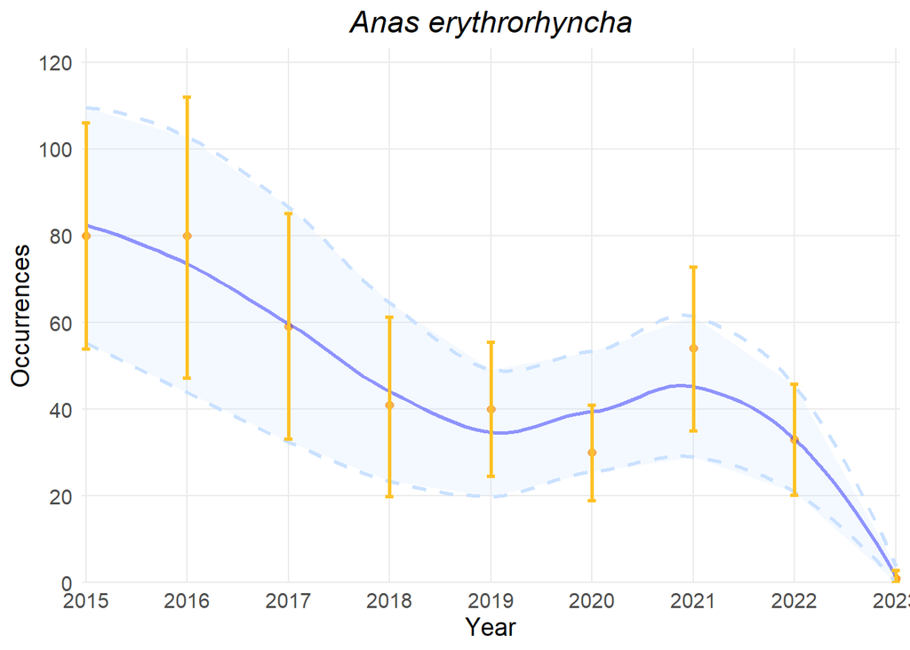

```r
plot(ts_spec_occ_sabap_HAA_pen, species = "Anas erythrorhyncha", y_expand = c(0, 0.1))
```

Maps of range - unstructured data

```r
map_spec_range_unstruc_HAA_pen <- spec_range_map(HAAunstruc, cell_size = 0.08333333, level = "cube", region = "South Africa", ne_scale = "medium")

plot(map_spec_range_unstruc_HAA_pen, species = "Anas erythrorhyncha")
```

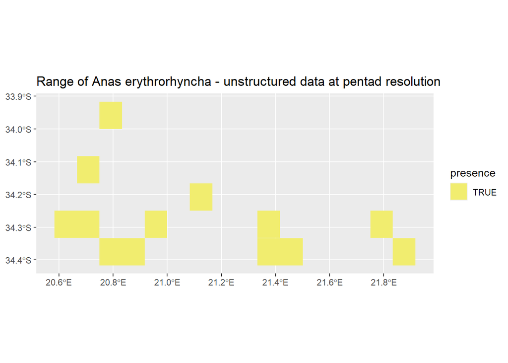

```r
UnstrucHAAinterim %>% filter(species == "Anas erythrorhyncha") %>% group_by(pentad) %>%
  summarise(n_rec = sum(n), .groups = "drop") %>%
  mutate(presence=case_when((n_rec > 0)~TRUE,
                                  TRUE~FALSE)) %>%
  ggplot() +
  geom_sf(aes(fill = presence), col = alpha("white", 0)) +
  scale_fill_manual(values = "#F1ED6FFF") +
  ggtitle("Range of Anas erythrorhyncha - unstructured data at pentad resolution")
```

```r
ts_spec_range_unstruc_HAA_pen <- spec_range_ts(HAAunstruc, cell_size = 0.08333333, level = "cube", region = "South Africa", ne_scale = "medium")
```

[output not shown]

[output cut: 61 more lines]

```
## $`Anas erythrorhyncha`
```

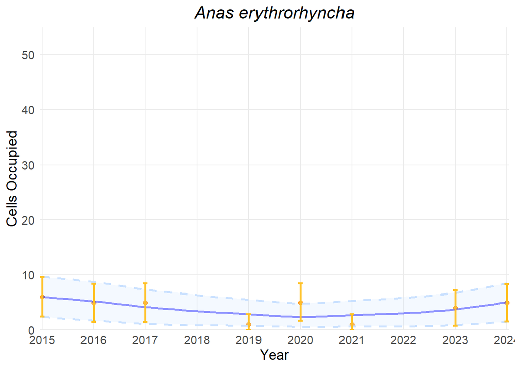

```r
plot(ts_spec_range_unstruc_HAA_pen, species = "Anas erythrorhyncha", y_expand = c(0, 4.7))
```

Maps of range - structured data

```r
map_spec_range_sabap_HAA_pen <- spec_range_map(HAASABAP2, cell_size = 0.08333333, level = "cube", region = "South Africa", ne_scale = "medium")

plot(map_spec_range_sabap_HAA_pen, species = "Anas erythrorhynchas")
```

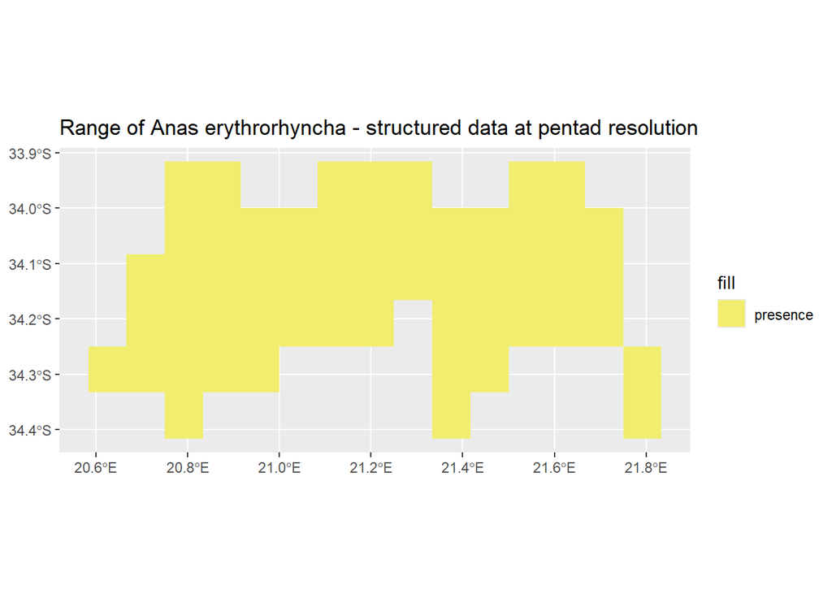

```r
SABAP2HAAGeom %>% filter(species == "Anas erythrorhyncha") %>% group_by(pentad) %>%
  summarise(n_rec = n(), .groups = "drop") %>%
  mutate(presence=case_when((n_rec > 0)~TRUE,
                                  TRUE~FALSE)) %>%
  ggplot() +
  geom_sf(aes(fill = "presence"), col = alpha("white", 0)) +
  scale_fill_manual(values = "#F1ED6FFF") +
  ggtitle("Range of Anas erythrorhyncha - structured data at pentad resolution")
```

Time series of range - structured data

```r
ts_spec_range_sabap_HAA_pen <- spec_range_ts(HAASABAP2, cell_size = 0.08333333, level = "cube", region = "South Africa", ne_scale = "medium")
```

[output not shown]

[output cut: 72 more lines]

```
## $`Anas erythrorhyncha`
```

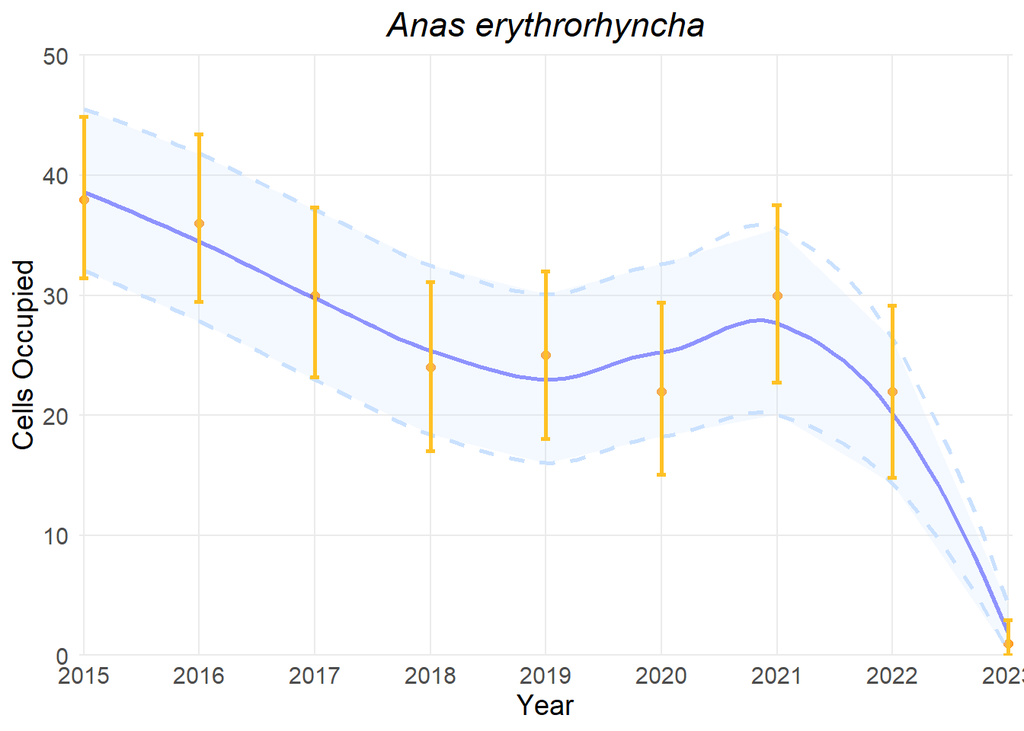

```r
plot(ts_spec_range_sabap_HAA_pen, species = "Anas erythrorhyncha", y_expand = c(0, 0.1))
```

**Turtur tympanistria** - a species for which records have remained stable

#### Quarter degree grid cell resolution

Maps of occurrence - unstructured data

```
## $`Turtur tympanistria`
```

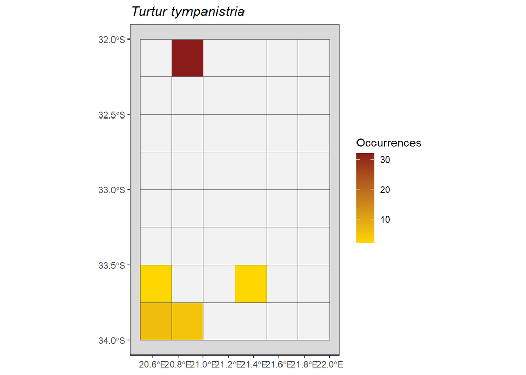

```r
plot(map_spec_occ_unstruc_HAA_QDGC, species = "Turtur tympanistria")
```

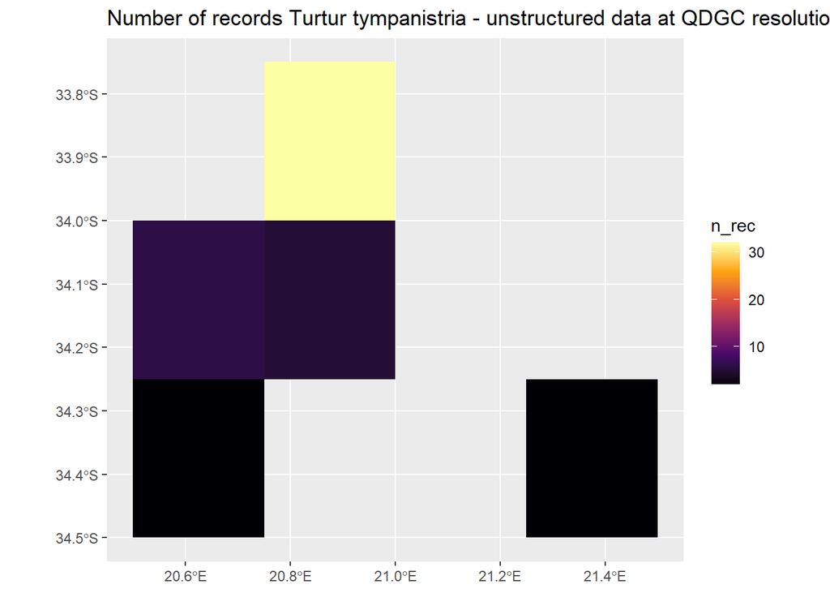

```r
UnstrucHAAQDGCinterim %>% filter(species == "Turtur tympanistria") %>% group_by(qdgc) %>%
  summarise(n_rec = sum(n), .groups = "drop") %>%
  ggplot() +
  geom_sf(aes(fill = n_rec), col = alpha("white", 0)) +
  scale_fill_viridis_c(option = "inferno") +
  ggtitle("Number of records Turtur tympanistria - unstructured data at QDGC resolution")
```

Time series of occurrence - unstructured data

```
## $`Turtur tympanistria`
```

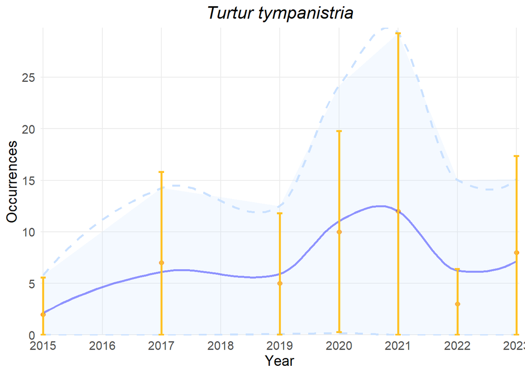

```r
plot(ts_spec_occ_unstruc_HAA_QDGC, species = "Turtur tympanistria")
```

Maps of occurrence - structured data

```
## $`Turtur tympanistria`
```

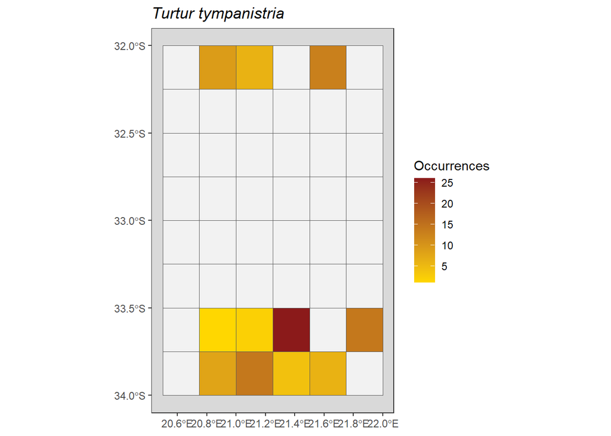

```r
plot(map_spec_occ_sabap_HAA_QDGC, species = "Turtur tympanistria")
```

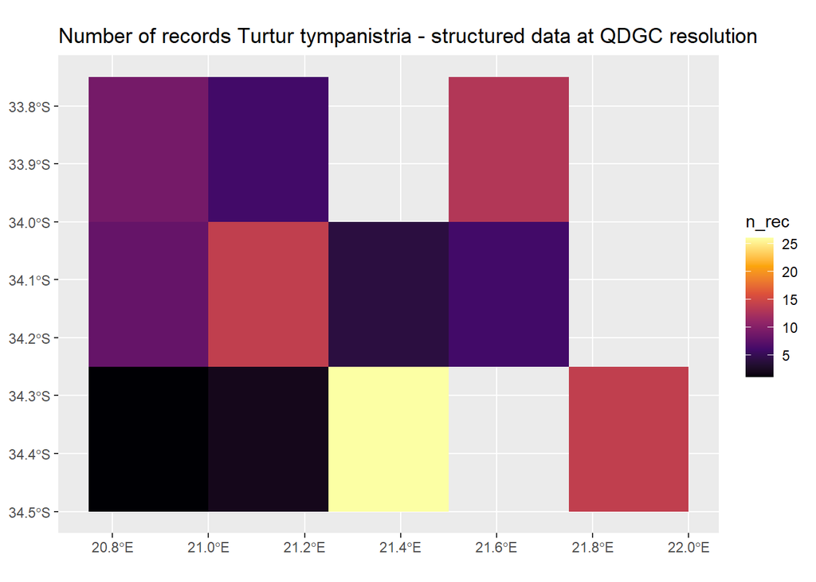

```r
SABAP2HAAQDGCGeom %>% filter(species == "Turtur tympanistria") %>%
  group_by(qdgc) %>%
  summarise(n_rec = n(), .groups = "drop") %>%
  ggplot() +
  geom_sf(aes(fill = n_rec), col = alpha("white", 0)) +
  scale_fill_viridis_c(option = "inferno") +
  ggtitle("Number of records Turtur tympanistria - structured data at QDGC resolution")
```

Time series of occurrence - structured data

```
## $`Turtur tympanistria`
```

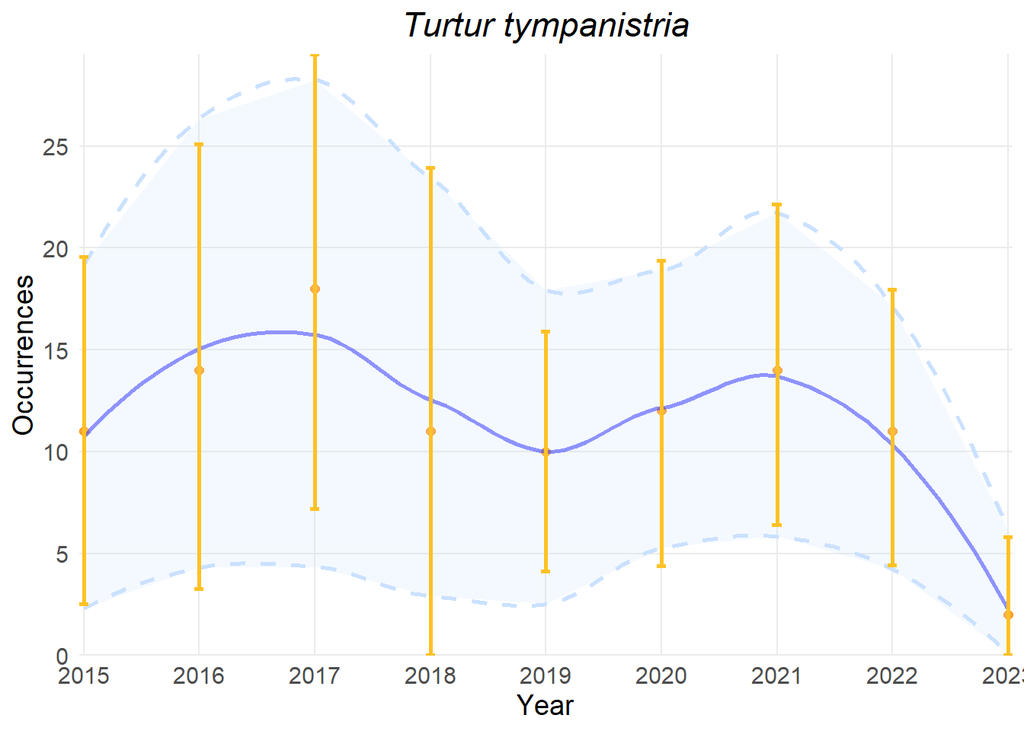

```r
plot(ts_spec_occ_sabap_HAA_QDGC, species = "Turtur tympanistria")
```

Maps of range - unstructured data

```
## $`Turtur tympanistria`
```

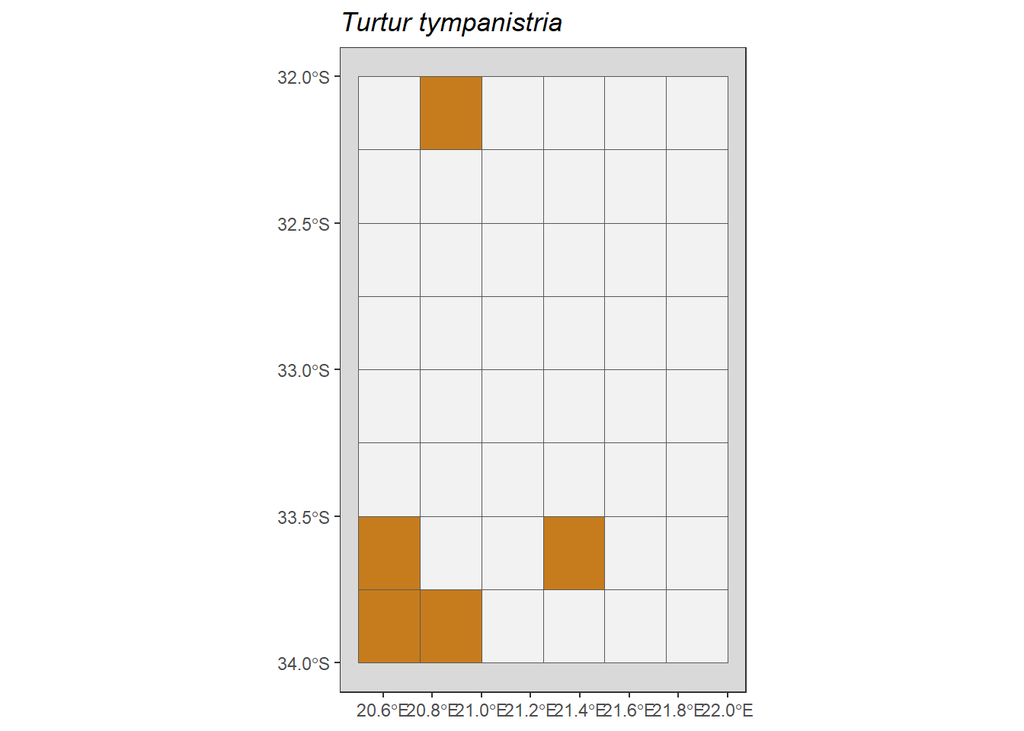

```r
plot(map_spec_range_unstruc_HAA_QDGC, species = "Turtur tympanistria")
```

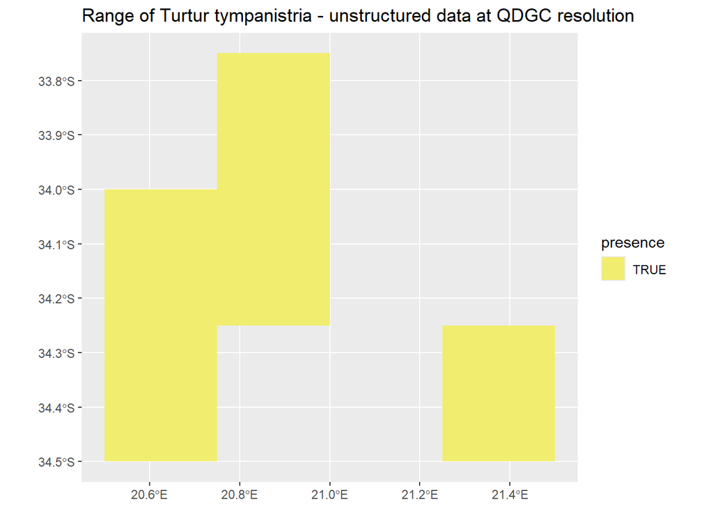

```r
UnstrucHAAQDGCinterim %>% filter(species == "Turtur tympanistria") %>% group_by(qdgc) %>%
  summarise(n_rec = sum(n), .groups = "drop") %>%
  mutate(presence=case_when((n_rec > 0)~TRUE,
                                  TRUE~FALSE)) %>%
  ggplot() +
  geom_sf(aes(fill = presence), col = alpha("white", 0)) +
  scale_fill_manual(values = "#F1ED6FFF") +
  ggtitle("Range of Turtur tympanistria - unstructured data at QDGC resolution")
```

Time series of range - unstructured data

```
## $`Turtur tympanistria`
```

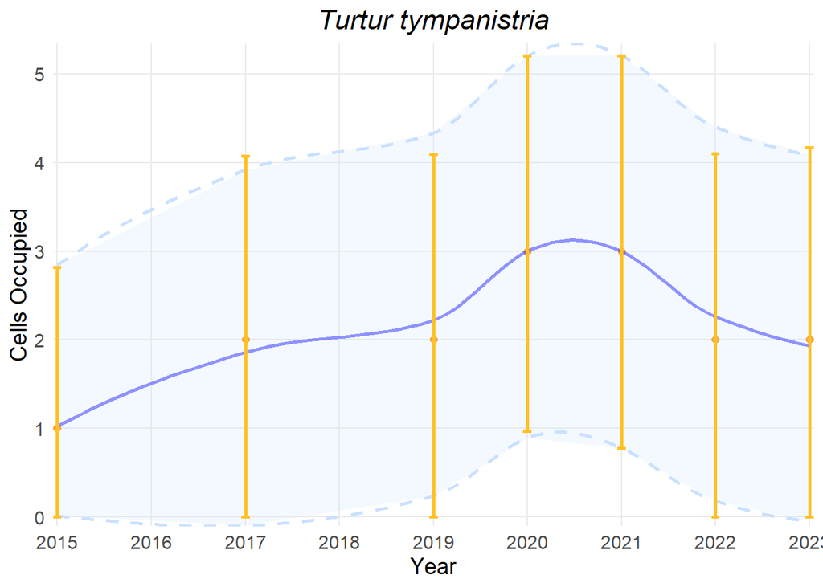

```r
plot(ts_spec_range_unstruc_HAA_QDGC, species = "Turtur tympanistria")
```

Maps of range - structured data

```
## $`Turtur tympanistria`
```

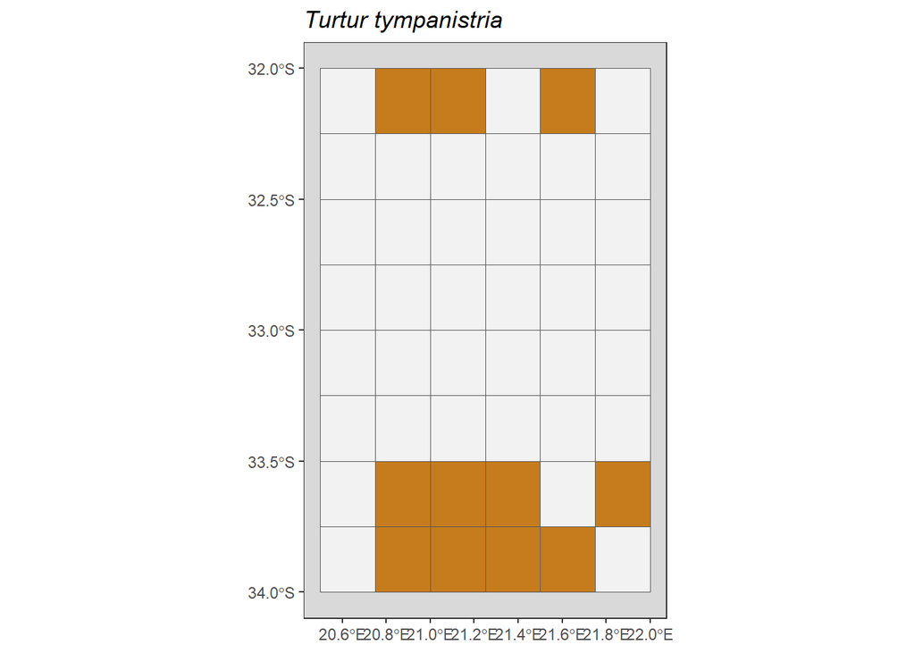

```r
plot(map_spec_range_sabap_HAA_QDGC, species = "Turtur tympanistria")
```

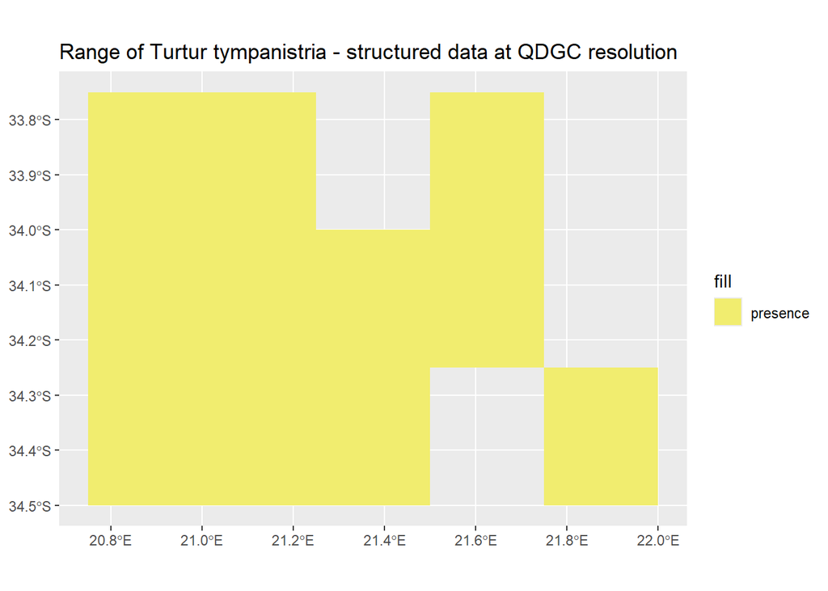

```r
SABAP2HAAQDGCGeom %>% filter(species == "Turtur tympanistria") %>% group_by(qdgc) %>%
  summarise(n_rec = n(), .groups = "drop") %>%
  mutate(presence=case_when((n_rec > 0)~TRUE,
                                  TRUE~FALSE)) %>%
  ggplot() +
  geom_sf(aes(fill = "presence"), col = alpha("white", 0)) +
  scale_fill_manual(values = "#F1ED6FFF") +
  ggtitle("Range of Turtur tympanistria - structured data at QDGC resolution")
```

Time series of range - structured data

```
## $`Turtur tympanistria`
```

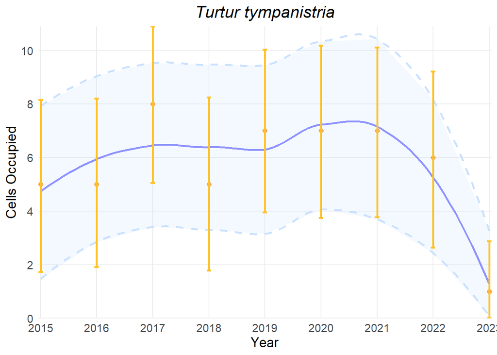

```r
plot(ts_spec_range_sabap_HAA_QDGC, species = "Turtur tympanistria")
```

#### Pentad resolution

Maps of occurrence - unstructured data

```r
map_spec_occ_unstruc_HAA_pen <- spec_occ_map(HAAunstruc, cell_size = 0.08333333, level = "cube", region = "South Africa", ne_scale = "medium")

plot(map_spec_occ_unstruc_HAA_pen, species = "Turtur tympanistria")
```

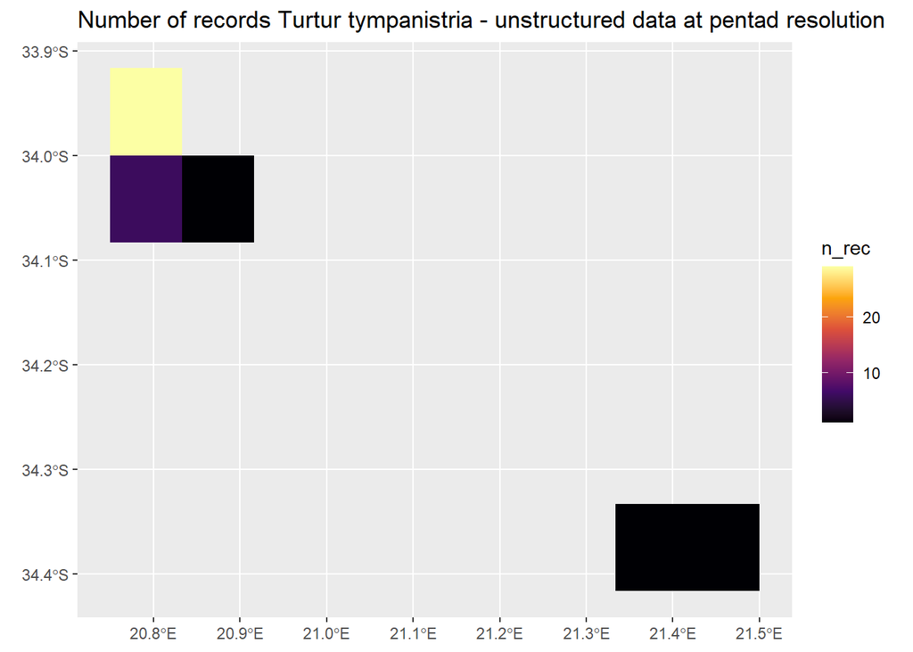

```r
UnstrucHAAinterim %>% filter(species == "Turtur tympanistria") %>% group_by(pentad) %>%
  summarise(n_rec = sum(n), .groups = "drop") %>%
  ggplot() +
  geom_sf(aes(fill = n_rec), col = alpha("white", 0)) +
  scale_fill_viridis_c(option = "inferno") +
  ggtitle("Number of records Turtur tympanistria - unstructured data at pentad resolution")
```

Time series of occurrence - unstructured data

```r
ts_spec_occ_unstruc_HAA_pen <- spec_occ_ts(HAAunstruc, cell_size = 0.08333333, level = "cube", region = "South Africa", ne_scale = "medium")
```

[output not shown]

[output cut: 52 more lines]

```
## $`Turtur tympanistria`
```

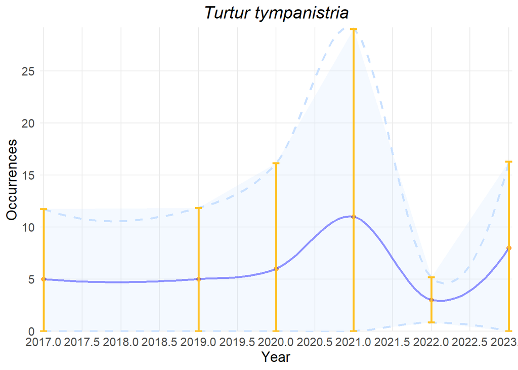

```r
plot(ts_spec_occ_unstruc_HAA_pen, species = "Turtur tympanistria")
```

Maps of occurrence - structured data

```r
map_spec_occ_sabap_HAA_pen <- spec_occ_map(HAASABAP2, cell_size = 0.08333333, level = "cube", region = "South Africa", ne_scale = "medium")

plot(map_spec_occ_sabap_HAA_pen, species = "Turtur tympanistria")
```

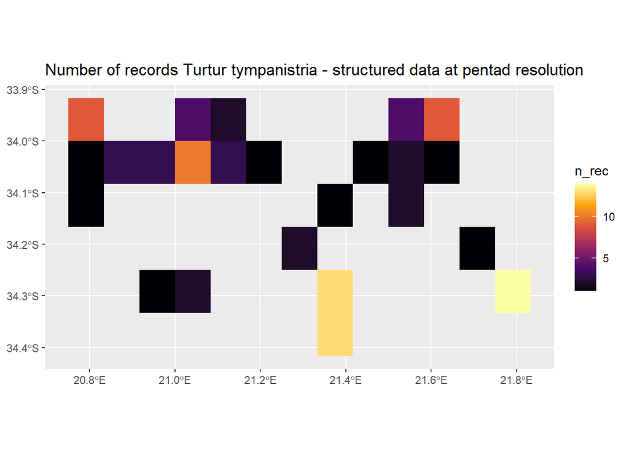

```r
SABAP2HAAGeom %>% filter(species == "Turtur tympanistria") %>%
  group_by(pentad) %>%
  summarise(n_rec = n(), .groups = "drop") %>%
  ggplot() +
  geom_sf(aes(fill = n_rec), col = alpha("white", 0)) +
  scale_fill_viridis_c(option = "inferno") +
  ggtitle("Number of records Turtur tympanistria - structured data at pentad resolution")
```

Time series of occurrence - structured data

```r
ts_spec_occ_sabap_HAA_pen <- spec_occ_ts(HAASABAP2, cell_size = 0.08333333, level = "cube", region = "South Africa", ne_scale = "medium")
```

[output not shown]

[output cut: 32 more lines]

```
## $`Turtur tympanistria`
```

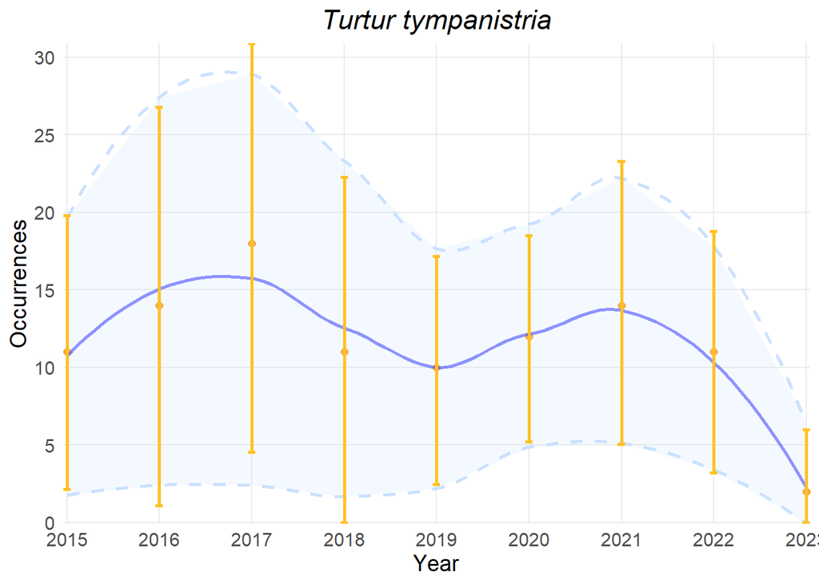

```r
plot(ts_spec_occ_sabap_HAA_pen, species = "Turtur tympanistria")
```

Maps of range - unstructured data

```r
map_spec_range_unstruc_HAA_pen <- spec_range_map(HAAunstruc, cell_size = 0.08333333, level = "cube", region = "South Africa", ne_scale = "medium")

plot(map_spec_range_unstruc_HAA_pen, species = "Turtur tympanistria")
```

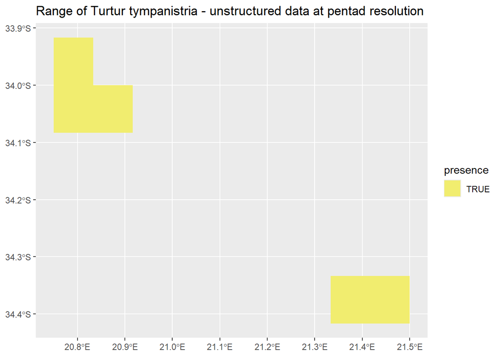

```r
UnstrucHAAinterim %>% filter(species == "Turtur tympanistria") %>% group_by(pentad) %>%
  summarise(n_rec = sum(n), .groups = "drop") %>%
  mutate(presence=case_when((n_rec > 0)~TRUE,
                                  TRUE~FALSE)) %>%
  ggplot() +
  geom_sf(aes(fill = presence), col = alpha("white", 0)) +
  scale_fill_manual(values = "#F1ED6FFF") +
  ggtitle("Range of Turtur tympanistria - unstructured data at pentad resolution")
```

```r
ts_spec_range_unstruc_HAA_pen <- spec_range_ts(HAAunstruc, cell_size = 0.08333333, level = "cube", region = "South Africa", ne_scale = "medium")
```

[output not shown]

[output cut: 61 more lines]

```
## $`Turtur tympanistria`
```

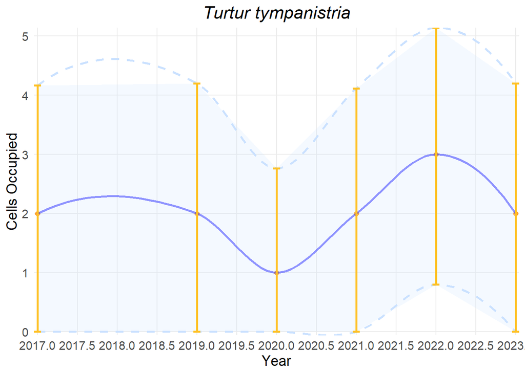

```r
plot(ts_spec_range_unstruc_HAA_pen, species = "Turtur tympanistria")
```

Maps of range - structured data

```r
map_spec_range_sabap_HAA_pen <- spec_range_map(HAASABAP2, cell_size = 0.08333333, level = "cube", region = "South Africa", ne_scale = "medium")

plot(map_spec_range_sabap_HAA_pen, species = "Turtur tympanistria")
```

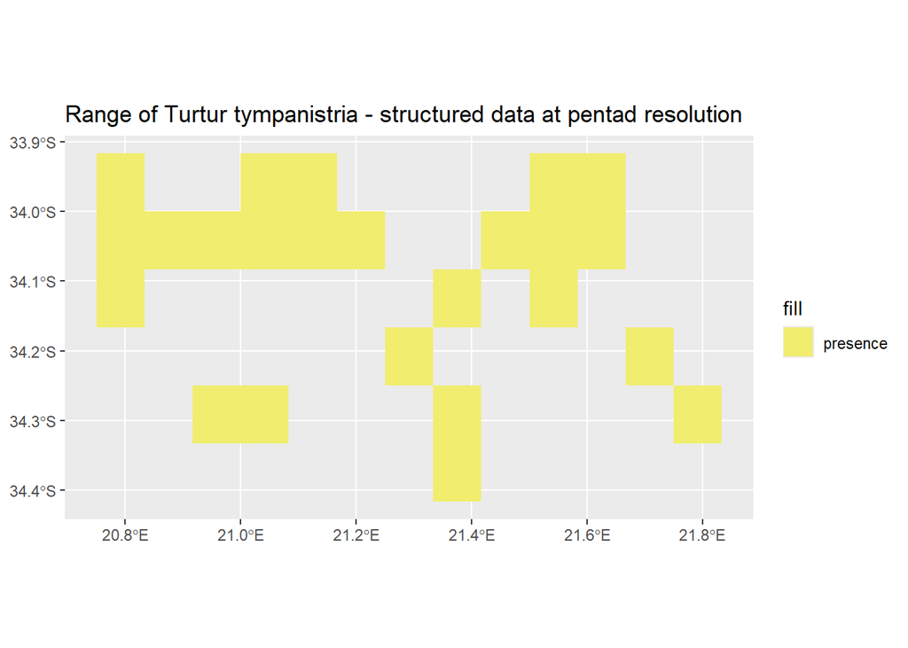

```r
SABAP2HAAGeom %>% filter(species == "Turtur tympanistria") %>% group_by(pentad) %>%
  summarise(n_rec = n(), .groups = "drop") %>%
  mutate(presence=case_when((n_rec > 0)~TRUE,
                                  TRUE~FALSE)) %>%
  ggplot() +
  geom_sf(aes(fill = "presence"), col = alpha("white", 0)) +
  scale_fill_manual(values = "#F1ED6FFF") +
  ggtitle("Range of Turtur tympanistria - structured data at pentad resolution")
```

Time series of range - structured data

```r
ts_spec_range_sabap_HAA_pen <- spec_range_ts(HAASABAP2, cell_size = 0.08333333, level = "cube", region = "South Africa", ne_scale = "medium")
```

[output not shown]

[output cut: 72 more lines]

```
## $`Turtur tympanistria`
```

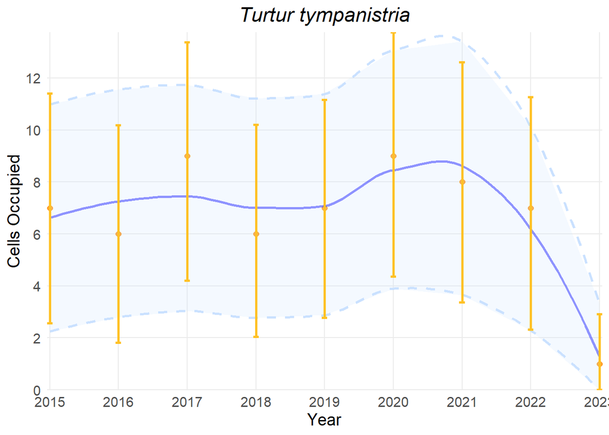

```r
plot(ts_spec_range_sabap_HAA_pen, species = "Turtur tympanistria")
```